# Who Comes Back? Machine Learning for ICU Readmission Prediction

Master of Science in Applied Data Science - Capstone Project

### Executive Summary

**The Challenge:** Despite $26 billion in annual readmission costs, predicting which ICU patients will return within 30 days remains unsolved.

**The Solution:** Machine learning model using 545,316 hospital admissions, 150M+ data points, and 57 engineered features.

**Key Results:**

- **0.683 AUC** — Correctly identifies 7 of 10 readmissions (49% better than baseline)
- **$17.25M annual value** — Net benefit for large academic hospitals
- **Efficient targeting** — Screen only 13 patients to prevent one readmission
- **Smart stratification** — Top 33% of patients contain 52.5% of readmissions

**Impact:** Enables hospitals to target high-risk patients for early intervention, reducing costly readmissions while optimizing resource allocation.

# 1. Introduction

Hospital readmissions represent a critical challenge in healthcare, with readmission rates remaining persistently high despite targeted interventions. Approximately 20% of Medicare beneficiaries experience readmission within 30 days, with average US hospital readmission rates of 14.67% across all conditions. Hospital readmissions cost approximately **$26 billion annually** in the United States.

This analysis aims to develop a predictive model for ICU readmissions using the MIMIC-IV dataset, focusing on identifying patients at high risk for readmission within 30 days of discharge.

# 2. Data Loading and Setup

## 2.1 Data Source: MIMIC-IV

The Medical Information Mart for Intensive Care (MIMIC-IV) is a large, freely-available database comprising de-identified health data from patients admitted to the Beth Israel Deaconess Medical Center between 2008-2019. This analysis uses six core data tables to construct a comprehensive view of patient trajectories through the ICU system.

**Why MIMIC-IV?** This dataset provides the clinical depth and scale necessary for developing robust readmission prediction models, with detailed information on diagnoses, medications, procedures, and laboratory results for over 500,000 hospital admissions.

```r
# Load required libraries
library(dplyr)
library(ggplot2)
library(data.table)
library(R.utils)
library(lubridate)
library(VIM)
library(knitr)
library(DT)
library(tidyr)
library(naniar)
library(rmdformats)
```

```r
# Load core datasets
cat('Loading MIMIC-IV datasets... \n')
```

```
## Loading MIMIC-IV datasets...
```

```r
admissions = fread('/Users/josephlattanzi/Scripts/Capstone/Data/admissions.csv.gz')
patients = fread('/Users/josephlattanzi/Scripts/Capstone/Data/patients.csv.gz')
diagnoses = fread('/Users/josephlattanzi/Scripts/Capstone/Data/diagnoses_icd.csv.gz')
prescriptions = fread('/Users/josephlattanzi/Scripts/Capstone/Data/prescriptions.csv.gz')
procedures = fread('/Users/josephlattanzi/Scripts/Capstone/Data/procedures_icd.csv.gz')
d_labitems = fread('/Users/josephlattanzi/Scripts/Capstone/Data/d_labitems.csv.gz')
d_icd_diagnoses = fread('/Users/josephlattanzi/Scripts/Capstone/Data/d_icd_diagnoses.csv.gz')
d_icd_procedures = fread('/Users/josephlattanzi/Scripts/Capstone/Data/d_icd_procedures.csv.gz')

# Load lab events data
cat('Loading lab events... \n')
```

```
## Loading lab events...
```

```r
labevents = fread('/Users/josephlattanzi/Scripts/Capstone/Data/labevents.csv.gz',
                  select = c('subject_id', 'hadm_id', 'itemid', 'charttime', 'valuenum'),
                  showProgress = TRUE)

# Filter to only lab events with valid numeric values and linked to admissions
labevents = labevents[!is.na(valuenum) & valuenum > 0 & !is.na(hadm_id)]

cat('Lab events filtered to', nrow(labevents), 'rows \n')
```

```
## Lab events filtered to 75308758 rows
```

```r
# Display dataset dimensions
data_summary = data.frame(
  Dataset = c('Admissions', 'Patients', 'Diagnoses', 'Prescriptions', 'Procedures', 'Lab Events'),
  Rows = c(nrow(admissions), nrow(patients), nrow(diagnoses), nrow(prescriptions), nrow(procedures), nrow(labevents)),
  Columns = c(ncol(admissions), ncol(patients), ncol(diagnoses), ncol(prescriptions), ncol(procedures), ncol(labevents))
)

nice_table(data_summary, caption = 'MIMIC-IV Dataset Overview')
```

MIMIC-IV Dataset Overview

| Dataset | Rows | Columns |
| --- | --- | --- |
| Admissions | 546028 | 16 |
| Patients | 364627 | 6 |
| Diagnoses | 6364488 | 5 |
| Prescriptions | 20292611 | 21 |
| Procedures | 859655 | 6 |
| Lab Events | 75308758 | 5 |

# 3. Data Preprocessing and Readmission Definition

## 3.1 Overview

Before building predictive models, we must carefully define our target variable (30-day readmission) and prepare our data for analysis. This section details the preprocessing steps taken to create a clean, analysis-ready dataset while avoiding common pitfalls like data leakage and temporal inconsistencies.

## 3.1 Admission Data Preprocessing

```r
# Convert dates to proper format
admissions$admittime = as.POSIXct(admissions$admittime)
admissions$dischtime = as.POSIXct(admissions$dischtime)

# Calculate length of stay
admissions$los_days = as.numeric(difftime(admissions$dischtime,
                                          admissions$admittime,
                                          units = 'days'))

# Remove invalid length of stay values
admissions = admissions %>% filter(los_days > 0 & los_days < 365)

cat('After filtering, admissions dataset contains', nrow(admissions), 'records\n')
```

```
## After filtering, admissions dataset contains 545847 records
```

## 3.2 Readmission Identification

```r
# Identify readmissions within 30 days
admissions = admissions %>%
  arrange(subject_id, admittime) %>%
  group_by(subject_id) %>%
  mutate(
    next_admission = lead(admittime),
    days_to_readmit = as.numeric(difftime(next_admission, dischtime, units = 'days')),
    readmit_30day = ifelse(days_to_readmit <= 30 & !is.na(days_to_readmit), 1, 0)
  ) %>%
  ungroup()

# Filter to eligible discharges (exclude last admission per patient)
readmit_eligible = admissions %>%
  filter(!is.na(readmit_30day))

# Calculate overall readmission statistics
readmit_summary = readmit_eligible %>%
  summarise(
    total_discharges = n(),
    readmissions = sum(readmit_30day),
    readmission_rate = mean(readmit_30day) * 100,
    .groups = 'drop'
  )

# Display results
summary_table = data.frame(
  Metric = c('Total Eligible Discharges', '30-Day Readmissions', '30-day Readmission Rate (%)'),
  Value = c(readmit_summary$total_discharges,
            readmit_summary$readmissions,
            round(readmit_summary$readmission_rate, 2))
)

nice_table(summary_table, caption = '30-Day Readmission Summary Statistics')
```

30-Day Readmission Summary Statistics

| Metric | Value |
| --- | --- |
| Total Eligible Discharges | 545847.00 |
| 30-Day Readmissions | 109339.00 |
| 30-day Readmission Rate (%) | 20.03 |

```r
cat('Eligible discharges for readmission analysis:', nrow(readmit_eligible), '\n')
```

```
## Eligible discharges for readmission analysis: 545847
```

# 4. Exploratory Data Analysis

## 4.1 Patient Demographics and Clinical Characteristics

```r
# Merge with patient data for demographics
analysis_data = readmit_eligible %>%
  left_join(patients, by = 'subject_id') %>%
  mutate(age_at_adm = anchor_age)

# Age comparison by readmission status
age_stats = analysis_data %>%
  group_by(readmit_30day) %>%
  summarise(
    count = n(),
    mean_age = round(mean(age_at_adm, na.rm = TRUE), 1),
    median_age = round(median(age_at_adm, na.rm = TRUE), 1),
    sd_age = round(sd(age_at_adm, na.rm = TRUE), 1),
    .groups = 'drop'
  ) %>%
  mutate(readmission_status = ifelse(readmit_30day == 1, 'Readmitted', 'Not Readmitted'))

nice_table(age_stats[, c('readmission_status', 'count', 'mean_age', 'median_age', 'sd_age')],
      caption = 'Age Statistics by Readmission Status',
      col.names = c('Readmission Status', 'Count', 'Mean Age', 'Median Age', 'SD Age'))
```

Age Statistics by Readmission Status

| Readmission Status | Count | Mean Age | Median Age | SD Age |
| --- | --- | --- | --- | --- |
| Not Readmitted | 436508 | 57.0 | 59 | 19.2 |
| Readmitted | 109339 | 56.5 | 58 | 18.1 |

```r
# Length of stay comparison
los_stats <- analysis_data %>%
  group_by(readmit_30day) %>%
  summarise(
    count = n(),
    mean_los = round(mean(los_days, na.rm = TRUE), 1),
    median_los = round(median(los_days, na.rm = TRUE), 1),
    q75_los = round(quantile(los_days, 0.75, na.rm = TRUE), 1),
    max_los = round(max(los_days, na.rm = TRUE), 1),
    .groups = 'drop'
  ) %>%
  mutate(readmission_status = ifelse(readmit_30day == 1, "Readmitted", "Not Readmitted"))

nice_table(los_stats[, c("readmission_status", "count", "mean_los", "median_los", "q75_los")],
      caption = "Length of Stay Statistics by Readmission Status",
      col.names = c("Readmission Status", "Count", "Mean LOS", "Median LOS", "75th Percentile LOS"))
```

Length of Stay Statistics by Readmission Status

| Readmission Status | Count | Mean LOS | Median LOS | 75th Percentile LOS |
| --- | --- | --- | --- | --- |
| Not Readmitted | 436508 | 4.6 | 2.7 | 5.3 |
| Readmitted | 109339 | 5.6 | 3.2 | 6.6 |

## 4.2 Diagnosis Analysis

```r
# Basic overview of diagnoses data
cat("Diagnoses data contains", nrow(diagnoses), "records for",
    length(unique(diagnoses$hadm_id)), "hospital admissions.\n")
```

```
## Diagnoses data contains 6364488 records for 545497 hospital admissions.
```

```r
cat("There are", length(unique(diagnoses$icd_code)), "unique ICD codes recorded.\n")
```

```
## There are 28562 unique ICD codes recorded.
```

```r
# Full integration with diagnosis dictionary
diagnoses_enhanced <- diagnoses %>%
  left_join(d_icd_diagnoses, by = c('icd_code' = 'icd_code', 'icd_version' = 'icd_version')) %>%
  mutate(
    # Use only long_title since short_title doesn't exist
    diagnosis_name = coalesce(long_title, paste("Unknown Diagnosis", icd_code)),
    # Create diagnosis categories based on ICD structure
    diagnosis_category = case_when(
      icd_version == 9 ~ case_when(
        substr(icd_code, 1, 3) %in% c("001", "002", "003") ~ "Infectious Diseases",
        substr(icd_code, 1, 1) == "1" ~ "Neoplasms",
        substr(icd_code, 1, 1) == "2" ~ "Endocrine/Metabolic",
        substr(icd_code, 1, 1) == "3" ~ "Blood Disorders",
        substr(icd_code, 1, 1) == "4" ~ "Circulatory System",
        substr(icd_code, 1, 1) == "5" ~ "Respiratory System",
        substr(icd_code, 1, 1) == "6" ~ "Digestive System",
        substr(icd_code, 1, 1) == "7" ~ "Genitourinary System",
        substr(icd_code, 1, 1) == "8" ~ "Injury/Poisoning",
        substr(icd_code, 1, 1) == "V" ~ "Supplementary Classification",
        TRUE ~ "Other ICD-9"
      ),
      icd_version == 10 ~ case_when(
        substr(icd_code, 1, 1) %in% c("A", "B") ~ "Infectious Diseases",
        substr(icd_code, 1, 1) == "C" ~ "Neoplasms",
        substr(icd_code, 1, 1) == "E" ~ "Endocrine/Metabolic",
        substr(icd_code, 1, 1) == "I" ~ "Circulatory System",
        substr(icd_code, 1, 1) == "J" ~ "Respiratory System",
        substr(icd_code, 1, 1) == "K" ~ "Digestive System",
        substr(icd_code, 1, 1) == "N" ~ "Genitourinary System",
        substr(icd_code, 1, 1) == "S" ~ "Injury/Poisoning",
        substr(icd_code, 1, 1) == "Z" ~ "Health Status Codes",
        TRUE ~ "Other ICD-10"
      ),
      TRUE ~ "Unknown Version"
    )
  )

# Check dictionary integration success
dict_integration_stats <- diagnoses_enhanced %>%
  summarise(
    total_records = n(),
    with_descriptions = sum(!is.na(long_title)),
    coverage_percent = round(sum(!is.na(long_title)) / n() * 100, 1),
    unique_categories = n_distinct(diagnosis_category)
  )

cat("\nDictionary Integration Results:\n")
```

```
##
## Dictionary Integration Results:
```

```r
cat("Total diagnosis records:", dict_integration_stats$total_records, "\n")
```

```
## Total diagnosis records: 6364488
```

```r
cat("Records with descriptions:", dict_integration_stats$with_descriptions, "\n")
```

```
## Records with descriptions: 6302153
```

```r
cat("Dictionary coverage:", dict_integration_stats$coverage_percent, "%\n")
```

```
## Dictionary coverage: 99 %
```

```r
cat("Unique diagnosis categories:", dict_integration_stats$unique_categories, "\n")
```

```
## Unique diagnosis categories: 13
```

```r
# Analyze by diagnosis categories
category_summary <- diagnoses_enhanced %>%
  group_by(diagnosis_category) %>%
  summarise(
    total_cases = n(),
    unique_codes = n_distinct(icd_code),
    unique_patients = n_distinct(subject_id),
    unique_admissions = n_distinct(hadm_id),
    percent_of_total = round(n() / nrow(diagnoses_enhanced) * 100, 1),
    .groups = 'drop'
  ) %>%
  arrange(desc(total_cases))

nice_table(category_summary, caption = 'Diagnosis Distribution by Clinical Category',
      col.names = c('Clinical Category', 'Total Cases', 'Unique Codes', 'Unique Patients',
                   'Unique Admissions', '% of Total'))
```

Diagnosis Distribution by Clinical Category

| Clinical Category | Total Cases | Unique Codes | Unique Patients | Unique Admissions | % of Total |
| --- | --- | --- | --- | --- | --- |
| Other ICD-10 | 1237594 | 9938 | 117747 | 241557 | 19.4 |
| Circulatory System | 1036150 | 1637 | 147973 | 368517 | 16.3 |
| Endocrine/Metabolic | 916377 | 1460 | 154429 | 378278 | 14.4 |
| Health Status Codes | 622212 | 898 | 101995 | 212170 | 9.8 |
| Genitourinary System | 504990 | 1770 | 123166 | 270317 | 7.9 |
| Respiratory System | 482787 | 937 | 109586 | 242789 | 7.6 |
| Supplementary Classification | 424778 | 728 | 85289 | 184494 | 6.7 |
| Digestive System | 316975 | 1524 | 88799 | 172084 | 5.0 |
| Blood Disorders | 297374 | 1098 | 76017 | 158579 | 4.7 |
| Other ICD-9 | 242739 | 1775 | 63452 | 112449 | 3.8 |
| Neoplasms | 123949 | 1186 | 31985 | 73059 | 1.9 |
| Injury/Poisoning | 90540 | 5134 | 38812 | 46953 | 1.4 |
| Infectious Diseases | 68023 | 498 | 31182 | 50894 | 1.1 |

```r
# Top diagnoses with full descriptions
icd_summary_enhanced <- diagnoses_enhanced %>%
  group_by(icd_code, icd_version, diagnosis_name, diagnosis_category) %>%
  summarise(
    frequency = n(),
    unique_patients = n_distinct(subject_id),
    unique_admissions = n_distinct(hadm_id),
    .groups = 'drop'
  ) %>%
  arrange(desc(frequency))

top_diagnoses_enhanced <- head(icd_summary_enhanced, 15) %>%
  mutate(
    # Truncate long descriptions for table readability
    diagnosis_display = ifelse(nchar(diagnosis_name) > 60,
                              paste0(substr(diagnosis_name, 1, 57), "..."),
                              diagnosis_name)
  )

nice_table(top_diagnoses_enhanced[, c('icd_code', 'icd_version', 'diagnosis_display', 'diagnosis_category', 'frequency', 'unique_patients')],
      caption = 'Top 15 Most Frequent Diagnoses with Clinical Categories',
      col.names = c('ICD Code', 'Version', 'Diagnosis', 'Category', 'Frequency', 'Unique Patients'))
```

Top 15 Most Frequent Diagnoses with Clinical Categories

| ICD Code | Version | Diagnosis | Category | Frequency | Unique Patients |
| --- | --- | --- | --- | --- | --- |
| 4019 | 9 | Unspecified essential hypertension | Circulatory System | 102368 | 52360 |
| E785 | 10 | Hyperlipidemia, unspecified | Endocrine/Metabolic | 84570 | 45431 |
| I10 | 10 | Essential (primary) hypertension | Circulatory System | 83775 | 48611 |
| 2724 | 9 | Other and unspecified hyperlipidemia | Endocrine/Metabolic | 67293 | 35210 |
| Z87891 | 10 | Personal history of nicotine dependence | Health Status Codes | 62806 | 32523 |
| K219 | 10 | Gastro-esophageal reflux disease without esophagitis | Digestive System | 56157 | 30093 |
| 53081 | 9 | Esophageal reflux | Respiratory System | 48628 | 25203 |
| 25000 | 9 | Diabetes mellitus without mention of complication, type I… | Endocrine/Metabolic | 43077 | 20384 |
| F329 | 10 | Major depressive disorder, single episode, unspecified | Other ICD-10 | 41876 | 23110 |
| I2510 | 10 | Atherosclerotic heart disease of native coronary artery w… | Circulatory System | 41550 | 20706 |
| F419 | 10 | Anxiety disorder, unspecified | Other ICD-10 | 38911 | 23305 |
| 42731 | 9 | Atrial fibrillation | Circulatory System | 37070 | 17290 |
| 4280 | 9 | Congestive heart failure, unspecified | Circulatory System | 36606 | 15162 |
| 311 | 9 | Depressive disorder, not elsewhere classified | Blood Disorders | 36349 | 20189 |
| 41401 | 9 | Coronary atherosclerosis of native coronary artery | Circulatory System | 36083 | 18820 |

```r
# Diagnoses per admission and readmission analysis using enhanced data
diagnoses_per_admission_enhanced = diagnoses_enhanced %>%
  group_by(hadm_id) %>%
  summarise(
    diagnoses_count = n(),
    unique_categories = n_distinct(diagnosis_category),
    has_circulatory = any(diagnosis_category == "Circulatory System"),
    has_respiratory = any(diagnosis_category == "Respiratory System"),
    has_endocrine = any(diagnosis_category == "Endocrine/Metabolic"),
    has_infectious = any(diagnosis_category == "Infectious Diseases"),
    .groups = 'drop'
  )

diagnoses_burden_table = diagnoses_per_admission_enhanced %>%
  summarise(
    mean_diagnoses = round(mean(diagnoses_count), 2),
    median_diagnoses = median(diagnoses_count),
    max_diagnoses = max(diagnoses_count),
    q75_diagnoses = quantile(diagnoses_count, 0.75),
    mean_categories = round(mean(unique_categories), 2)
  )

diagnoses_summary_table = data.frame(
  Metric = c('Mean Diagnoses per Admission', 'Median Diagnoses per Admission',
             '75th Percentile Diagnoses', 'Max Diagnoses per Admission',
             'Mean Diagnostic Categories per Admission'),
  Value = c(diagnoses_burden_table$mean_diagnoses,
            diagnoses_burden_table$median_diagnoses,
            diagnoses_burden_table$q75_diagnoses,
            diagnoses_burden_table$max_diagnoses,
            diagnoses_burden_table$mean_categories)
)

nice_table(diagnoses_summary_table, caption = 'Enhanced Diagnoses Burden per Admission')
```

Enhanced Diagnoses Burden per Admission

| Metric | Value |
| --- | --- |
| Mean Diagnoses per Admission | 11.67 |
| Median Diagnoses per Admission | 10.00 |
| 75th Percentile Diagnoses | 16.00 |
| Max Diagnoses per Admission | 57.00 |
| Mean Diagnostic Categories per Admission | 4.61 |

```r
# Merge enhanced diagnoses data with analysis dataset
admission_diagnoses_enhanced = diagnoses_enhanced %>%
  group_by(hadm_id) %>%
  summarise(
    total_diagnoses = n(),
    unique_diagnosis_categories = n_distinct(diagnosis_category),
    primary_diagnosis_code = first(icd_code[seq_num == 1]),
    primary_diagnosis_name = first(diagnosis_name[seq_num == 1]),
    primary_diagnosis_category = first(diagnosis_category[seq_num == 1]),
    # High-risk diagnosis flags
    has_heart_failure = any(grepl("heart failure|cardiac failure", diagnosis_name, ignore.case = TRUE)),
    has_diabetes = any(grepl("diabetes", diagnosis_name, ignore.case = TRUE)),
    has_copd = any(grepl("chronic obstructive|copd|emphysema", diagnosis_name, ignore.case = TRUE)),
    has_pneumonia = any(grepl("pneumonia", diagnosis_name, ignore.case = TRUE)),
    .groups = 'drop'
  )

analysis_data = analysis_data %>%
  left_join(admission_diagnoses_enhanced, by = 'hadm_id')

# High-risk diagnoses and readmission analysis
high_risk_conditions <- analysis_data %>%
  summarise(
    heart_failure_readmit_rate = round(mean(readmit_30day[has_heart_failure == TRUE], na.rm = TRUE) * 100, 1),
    diabetes_readmit_rate = round(mean(readmit_30day[has_diabetes == TRUE], na.rm = TRUE) * 100, 1),
    copd_readmit_rate = round(mean(readmit_30day[has_copd == TRUE], na.rm = TRUE) * 100, 1),
    pneumonia_readmit_rate = round(mean(readmit_30day[has_pneumonia == TRUE], na.rm = TRUE) * 100, 1),
    overall_readmit_rate = round(mean(readmit_30day, na.rm = TRUE) * 100, 1)
  )

high_risk_table <- data.frame(
  Condition = c('Heart Failure', 'Diabetes', 'COPD', 'Pneumonia', 'Overall'),
  Readmission_Rate = c(high_risk_conditions$heart_failure_readmit_rate,
                       high_risk_conditions$diabetes_readmit_rate,
                       high_risk_conditions$copd_readmit_rate,
                       high_risk_conditions$pneumonia_readmit_rate,
                       high_risk_conditions$overall_readmit_rate)
)

nice_table(high_risk_table, caption = 'Readmission Rates by High-Risk Conditions',
      col.names = c('Condition', 'Readmission Rate (%)'))
```

Readmission Rates by High-Risk Conditions

| Condition | Readmission Rate (%) |
| --- | --- |
| Heart Failure | 23.5 |
| Diabetes | 22.3 |
| COPD | 21.7 |
| Pneumonia | 20.9 |
| Overall | 20.0 |

```r
# Primary diagnosis category analysis
primary_dx_category_analysis = analysis_data %>%
  group_by(primary_diagnosis_category) %>%
  summarise(
    total_cases = n(),
    readmissions = sum(readmit_30day, na.rm = TRUE),
    readmission_rate = round(mean(readmit_30day, na.rm = TRUE) * 100, 1),
    .groups = 'drop'
  ) %>%
  filter(total_cases >= 20 & !is.na(primary_diagnosis_category)) %>%
  arrange(desc(readmission_rate))

nice_table(primary_dx_category_analysis, caption = 'Readmission Rates by Primary Diagnosis Category',
      col.names = c('Primary Diagnosis Category', 'Total Cases', 'Readmissions', 'Readmission Rate (%)'))
```

Readmission Rates by Primary Diagnosis Category

| Primary Diagnosis Category | Total Cases | Readmissions | Readmission Rate (%) |
| --- | --- | --- | --- |
| Health Status Codes | 6230 | 2917 | 46.8 |
| Supplementary Classification | 6604 | 3036 | 46.0 |
| Endocrine/Metabolic | 40032 | 10532 | 26.3 |
| Neoplasms | 26331 | 6762 | 25.7 |
| Blood Disorders | 21502 | 5474 | 25.5 |
| Other ICD-9 | 30475 | 6879 | 22.6 |
| Respiratory System | 58141 | 12463 | 21.4 |
| Infectious Diseases | 12500 | 2394 | 19.2 |
| Other ICD-10 | 97978 | 18590 | 19.0 |
| Circulatory System | 100557 | 18049 | 17.9 |
| Digestive System | 53501 | 8998 | 16.8 |
| Genitourinary System | 59134 | 9635 | 16.3 |
| Injury/Poisoning | 32331 | 3475 | 10.7 |

```r
# Enhanced diagnosis burden by readmission status
diagnosis_burden_enhanced = analysis_data %>%
  group_by(readmit_30day) %>%
  summarise(
    mean_diagnoses = round(mean(total_diagnoses, na.rm = TRUE), 2),
    median_diagnoses = median(total_diagnoses, na.rm = TRUE),
    mean_categories = round(mean(unique_diagnosis_categories, na.rm = TRUE), 2),
    q75_diagnoses = quantile(total_diagnoses, 0.75, na.rm = TRUE),
    .groups = 'drop'
  ) %>%
  mutate(readmission_status = ifelse(readmit_30day == 1, 'Readmitted', 'Not Readmitted'))

nice_table(diagnosis_burden_enhanced[, c('readmission_status', 'mean_diagnoses', 'median_diagnoses', 'mean_categories', 'q75_diagnoses')],
      caption = 'Enhanced Diagnosis Burden by Readmission Status',
      col.names = c('Readmission Status', 'Mean Diagnoses', 'Median Diagnoses', 'Mean Categories', '75th Percentile'))
```

Enhanced Diagnosis Burden by Readmission Status

| Readmission Status | Mean Diagnoses | Median Diagnoses | Mean Categories | 75th Percentile |
| --- | --- | --- | --- | --- |
| Not Readmitted | 11.34 | 10 | 4.53 | 15 |
| Readmitted | 12.97 | 12 | 4.92 | 18 |

## 4.3 Prescription Analysis

```r
cat('Prescriptions dataset contains', nrow(prescriptions), 'records\n')
```

```
## Prescriptions dataset contains 20292611 records
```

```r
cat('Unique patients:', length(unique(prescriptions$subject_id)), '\n')
```

```
## Unique patients: 196738
```

```r
cat('Unique admissions:', length(unique(prescriptions$hadm_id)), '\n')
```

```
## Unique admissions: 463328
```

```r
cat('Unique medications:', length(unique(prescriptions$drug)), '\n')
```

```
## Unique medications: 10582
```

```r
# Enhanced prescription analysis with drug categorization
prescriptions_enhanced <- prescriptions %>%
  mutate(
    # Clean drug names for better categorization
    drug_clean = toupper(trimws(drug)),
    # Create therapeutic categories based on drug names
    drug_category = case_when(
        # IV Fluids and Electrolytes
        grepl("SODIUM CHLORIDE|DEXTROSE|LACTATED RINGERS|POTASSIUM CHLORIDE|MAGNESIUM SULFATE|CALCIUM GLUCONATE|STERILE WATER|GLUCOSE GEL|^NS$", drug_clean) ~ "IV Fluids/Electrolytes",

        # Pain Management
        grepl("HYDROMORPHONE|DILAUDID|MORPHINE|FENTANYL|OXYCODONE|TRAMADOL|ACETAMINOPHEN|IBUPROFEN|GABAPENTIN", drug_clean) ~ "Pain Management",

        # Anticoagulants (major category we missed)
        grepl("HEPARIN|WARFARIN|ASPIRIN", drug_clean) ~ "Anticoagulants",

        # CNS/Psychiatric Medications
        grepl("LORAZEPAM|ALPRAZOLAM|MIDAZOLAM|HALOPERIDOL", drug_clean) ~ "CNS Medications",

        # Proton Pump Inhibitors/GI
        grepl("PANTOPRAZOLE|OMEPRAZOLE|LANSOPRAZOLE|PROTONIX|SENNA|DOCUSATE|BISACODYL|POLYETHYLENE GLYCOL", drug_clean) ~ "GI Medications",

        # Cardiovascular (add statin)
        grepl("LISINOPRIL|METOPROLOL|ATENOLOL|AMLODIPINE|FUROSEMIDE|LASIX|ATORVASTATIN", drug_clean) ~ "Cardiovascular",

        # Corticosteroids
        grepl("PREDNISONE|PREDNISOLONE|METHYLPREDNISOLONE", drug_clean) ~ "Corticosteroids",

        # Anti-nausea
        grepl("ONDANSETRON|ZOFRAN", drug_clean) ~ "Anti-nausea",

        # Diabetes/Metabolic
        grepl("GLUCAGON|INSULIN|METFORMIN", drug_clean) ~ "Diabetes/Metabolic",

        # Antibiotics
        grepl("VANCOMYCIN|CIPROFLOXACIN|LEVOFLOXACIN|CEFTRIAXONE|AZITHROMYCIN", drug_clean) ~ "Antibiotics",

        # Administration/Container
        grepl("^BAG$|^VIAL$|^SW$|FLUSH", drug_clean) ~ "Administration/Container",

        TRUE ~ "Other/Unclassified"
      ),
    # High-risk medication flags
    high_risk_med = drug_category %in% c("Anticoagulants", "Opioid Analgesics", "CNS Medications"),
    # Route categorization
    route_category = case_when(
      grepl("IV|INTRAVENOUS", toupper(coalesce(route, ""))) ~ "Intravenous",
      grepl("PO|ORAL", toupper(coalesce(route, ""))) ~ "Oral",
      grepl("IM|INTRAMUSCULAR", toupper(coalesce(route, ""))) ~ "Intramuscular",
      grepl("SL|SUBLINGUAL", toupper(coalesce(route, ""))) ~ "Sublingual",
      grepl("TOP|TOPICAL", toupper(coalesce(route, ""))) ~ "Topical",
      TRUE ~ "Other/Unknown"
    )
  )

# Drug category analysis
drug_category_summary <- prescriptions_enhanced %>%
  group_by(drug_category) %>%
  summarise(
    total_prescriptions = n(),
    unique_drugs = n_distinct(drug),
    unique_patients = n_distinct(subject_id),
    unique_admissions = n_distinct(hadm_id),
    percent_of_total = round(n() / nrow(prescriptions_enhanced) * 100, 1),
    .groups = 'drop'
  ) %>%
  arrange(desc(total_prescriptions))

nice_table(drug_category_summary, caption = 'Prescription Distribution by Therapeutic Category',
      col.names = c('Therapeutic Category', 'Total Prescriptions', 'Unique Drugs',
                   'Unique Patients', 'Unique Admissions', '% of Total'))
```

Prescription Distribution by Therapeutic Category

| Therapeutic Category | Total Prescriptions | Unique Drugs | Unique Patients | Unique Admissions | % of Total |
| --- | --- | --- | --- | --- | --- |
| Other/Unclassified | 7023243 | 9782 | 195008 | 459802 | 34.6 |
| IV Fluids/Electrolytes | 4731040 | 114 | 190701 | 446748 | 23.3 |
| Pain Management | 1980405 | 192 | 186277 | 416954 | 9.8 |
| GI Medications | 1337925 | 83 | 167945 | 375430 | 6.6 |
| Cardiovascular | 1175213 | 46 | 110302 | 260773 | 5.8 |
| Anticoagulants | 1112254 | 77 | 154182 | 354388 | 5.5 |
| Diabetes/Metabolic | 1054224 | 144 | 72242 | 152432 | 5.2 |
| Administration/Container | 636516 | 9 | 98294 | 179960 | 3.1 |
| Antibiotics | 464514 | 52 | 86951 | 158922 | 2.3 |
| CNS Medications | 351470 | 28 | 75614 | 134967 | 1.7 |
| Anti-nausea | 284631 | 11 | 107506 | 191890 | 1.4 |
| Corticosteroids | 141176 | 44 | 24437 | 53522 | 0.7 |

```r
# Top medications with categories
medication_summary_enhanced = prescriptions_enhanced %>%
  group_by(drug, drug_category) %>%
  summarise(
    frequency = n(),
    unique_patients = n_distinct(subject_id),
    unique_admissions = n_distinct(hadm_id),
    .groups = 'drop'
  ) %>%
  arrange(desc(frequency)) %>%
  top_n(20, wt = frequency)

nice_table(medication_summary_enhanced, caption = 'Top 20 Medications by Frequency with Therapeutic Categories',
      col.names = c('Medication', 'Therapeutic Category', 'Total Prescriptions', 'Unique Patients', 'Unique Admissions'))
```

Top 20 Medications by Frequency with Therapeutic Categories

| Medication | Therapeutic Category | Total Prescriptions | Unique Patients | Unique Admissions |
| --- | --- | --- | --- | --- |
| Insulin | Diabetes/Metabolic | 845177 | 69308 | 145367 |
| 0.9% Sodium Chloride | IV Fluids/Electrolytes | 728089 | 105609 | 184098 |
| Potassium Chloride | IV Fluids/Electrolytes | 674578 | 87938 | 151301 |
| Sodium Chloride 0.9% Flush | IV Fluids/Electrolytes | 673380 | 184244 | 419881 |
| Acetaminophen | Pain Management | 586864 | 170688 | 353236 |
| Furosemide | Cardiovascular | 446725 | 54532 | 104232 |
| Heparin | Anticoagulants | 396613 | 136801 | 279200 |
| 5% Dextrose | IV Fluids/Electrolytes | 368167 | 71337 | 112176 |
| Magnesium Sulfate | IV Fluids/Electrolytes | 367223 | 83218 | 144291 |
| Bag | Administration/Container | 352882 | 72102 | 122708 |
| Senna | GI Medications | 340034 | 124135 | 236998 |
| Docusate Sodium | GI Medications | 336484 | 131913 | 252031 |
| HYDROmorphone (Dilaudid) | Pain Management | 333116 | 69456 | 111110 |
| Iso-Osmotic Dextrose | IV Fluids/Electrolytes | 308278 | 81846 | 128965 |
| Metoprolol Tartrate | Cardiovascular | 301566 | 55035 | 97221 |
| Ondansetron | Anti-nausea | 268274 | 105832 | 186014 |
| Lactated Ringers | IV Fluids/Electrolytes | 248501 | 83620 | 124279 |
| Sodium Chloride 0.9% | IV Fluids/Electrolytes | 230725 | 56648 | 91522 |
| Vancomycin | Antibiotics | 229583 | 54837 | 85788 |
| Bisacodyl | GI Medications | 225914 | 86916 | 130483 |

```r
# Enhanced polypharmacy analysis with categories
medications_per_admission_enhanced = prescriptions_enhanced %>%
  group_by(hadm_id) %>%
  summarise(
    medication_count = n(),
    unique_medications = n_distinct(drug),
    unique_categories = n_distinct(drug_category),
    high_risk_med_count = sum(high_risk_med),
    has_diabetes_meds = any(drug_category == "Diabetes Medications"),
    has_cv_meds = any(drug_category == "Cardiovascular"),
    has_antibiotics = any(drug_category == "Antibiotics"),
    has_opioids = any(drug_category == "Opioid Analgesics"),
    .groups = 'drop'
  )

polypharmacy_enhanced_stats = medications_per_admission_enhanced %>%
  summarise(
    mean_medications = round(mean(medication_count), 1),
    median_medications = median(medication_count),
    max_medications = max(medication_count),
    q75_medications = quantile(medication_count, 0.75),
    mean_categories = round(mean(unique_categories), 1),
    median_categories = median(unique_categories),
    mean_high_risk = round(mean(high_risk_med_count), 1)
  )

polypharmacy_enhanced_table = data.frame(
  Metric = c('Mean Medications per Admission', 'Median Medications per Admission',
             '75th Percentile Medications', 'Max Medications per Admission',
             'Mean Therapeutic Categories', 'Median Therapeutic Categories',
             'Mean High-Risk Medications'),
  Value = c(polypharmacy_enhanced_stats$mean_medications,
            polypharmacy_enhanced_stats$median_medications,
            polypharmacy_enhanced_stats$q75_medications,
            polypharmacy_enhanced_stats$max_medications,
            polypharmacy_enhanced_stats$mean_categories,
            polypharmacy_enhanced_stats$median_categories,
            polypharmacy_enhanced_stats$mean_high_risk)
)

nice_table(polypharmacy_enhanced_table, caption = 'Enhanced Polypharmacy Metrics per Admission')
```

Enhanced Polypharmacy Metrics per Admission

| Metric | Value |
| --- | --- |
| Mean Medications per Admission | 43.8 |
| Median Medications per Admission | 28.0 |
| 75th Percentile Medications | 49.0 |
| Max Medications per Admission | 2812.0 |
| Mean Therapeutic Categories | 6.9 |
| Median Therapeutic Categories | 7.0 |
| Mean High-Risk Medications | 3.2 |

```r
# Remove existing medication variables before joining
analysis_data <- analysis_data %>%
  select(-any_of(c("medication_count", "unique_medications", "unique_categories",
                   "high_risk_med_count", "has_diabetes_meds", "has_cv_meds",
                   "has_antibiotics", "has_opioids")))

# Merge enhanced prescription data with analysis dataset AND clean in one step
analysis_data = analysis_data %>%
  left_join(medications_per_admission_enhanced, by = 'hadm_id') %>%
  mutate(
    medication_count = ifelse(is.na(medication_count), 0, medication_count),
    unique_medications = ifelse(is.na(unique_medications), 0, unique_medications),
    unique_categories = ifelse(is.na(unique_categories), 0, unique_categories),
    high_risk_med_count = ifelse(is.na(high_risk_med_count), 0, high_risk_med_count),
    has_diabetes_meds = ifelse(is.na(has_diabetes_meds), FALSE, has_diabetes_meds),
    has_cv_meds = ifelse(is.na(has_cv_meds), FALSE, has_cv_meds),
    has_antibiotics = ifelse(is.na(has_antibiotics), FALSE, has_antibiotics),
    has_opioids = ifelse(is.na(has_opioids), FALSE, has_opioids)
  )

# High-risk medication analysis and readmission
high_risk_med_analysis <- analysis_data %>%
  summarise(
    diabetes_meds_readmit_rate = round(mean(readmit_30day[has_diabetes_meds == TRUE], na.rm = TRUE) * 100, 1),
    cv_meds_readmit_rate = round(mean(readmit_30day[has_cv_meds == TRUE], na.rm = TRUE) * 100, 1),
    antibiotics_readmit_rate = round(mean(readmit_30day[has_antibiotics == TRUE], na.rm = TRUE) * 100, 1),
    opioids_readmit_rate = round(mean(readmit_30day[has_opioids == TRUE], na.rm = TRUE) * 100, 1),
    overall_readmit_rate = round(mean(readmit_30day, na.rm = TRUE) * 100, 1)
  )

med_risk_table <- data.frame(
  Medication_Category = c('Diabetes Medications', 'Cardiovascular', 'Antibiotics', 'Opioids', 'Overall'),
  Readmission_Rate = c(high_risk_med_analysis$diabetes_meds_readmit_rate,
                       high_risk_med_analysis$cv_meds_readmit_rate,
                       high_risk_med_analysis$antibiotics_readmit_rate,
                       high_risk_med_analysis$opioids_readmit_rate,
                       high_risk_med_analysis$overall_readmit_rate)
)

nice_table(med_risk_table, caption = 'Readmission Rates by Medication Categories',
      col.names = c('Medication Category', 'Readmission Rate (%)'))
```

Readmission Rates by Medication Categories

| Medication Category | Readmission Rate (%) |
| --- | --- |
| Diabetes Medications | NaN |
| Cardiovascular | 21.1 |
| Antibiotics | 22.2 |
| Opioids | NaN |
| Overall | 20.0 |

```r
# Enhanced prescription burden by readmission status
prescription_readmission_enhanced = analysis_data %>%
  group_by(readmit_30day) %>%
  summarise(
    mean_prescriptions = round(mean(medication_count, na.rm = TRUE), 2),
    median_prescriptions = median(medication_count, na.rm = TRUE),
    mean_categories = round(mean(unique_categories, na.rm = TRUE), 2),
    mean_high_risk = round(mean(high_risk_med_count, na.rm = TRUE), 2),
    q75_prescriptions = quantile(medication_count, 0.75, na.rm = TRUE),
    .groups = 'drop'
  ) %>%
  mutate(readmission_status = ifelse(readmit_30day == 1, 'Readmitted', 'Not Readmitted'))

nice_table(prescription_readmission_enhanced[, c('readmission_status', 'mean_prescriptions', 'median_prescriptions', 'mean_categories', 'mean_high_risk')],
      caption = 'Enhanced Prescription Burden by Readmission Status',
      col.names = c('Readmission Status', 'Mean Prescriptions', 'Median Prescriptions', 'Mean Categories', 'Mean High-Risk Meds'))
```

Enhanced Prescription Burden by Readmission Status

| Readmission Status | Mean Prescriptions | Median Prescriptions | Mean Categories | Mean High-Risk Meds |
| --- | --- | --- | --- | --- |
| Not Readmitted | 35.73 | 22 | 5.77 | 2.55 |
| Readmitted | 42.89 | 29 | 6.10 | 3.19 |

## 4.4 Laboratory Values Analysis

```r
cat('Lab events dataset contains', nrow(labevents), 'records\n')
```

```
## Lab events dataset contains 75308758 records
```

```r
cat('Unique patients:', length(unique(labevents$subject_id)), '\n')
```

```
## Unique patients: 191167
```

```r
cat('Unique admissions:', length(unique(labevents$hadm_id)), '\n')
```

```
## Unique admissions: 446792
```

```r
cat('Unique lab tests:', length(unique(labevents$itemid)), '\n')
```

```
## Unique lab tests: 600
```

```r
# Memory-efficient approach: Skip individual lab enhancement, go straight to aggregates
labs_per_admission_enhanced = labevents %>%
  left_join(d_labitems, by = 'itemid') %>%
  group_by(hadm_id) %>%
  summarise(
    total_lab_tests = n(),
    unique_lab_types = n_distinct(itemid),
    unique_categories = n_distinct(category, na.rm = TRUE),
    # Count specific important lab categories
    chemistry_tests = sum(grepl("chemistry", category, ignore.case = TRUE), na.rm = TRUE),
    hematology_tests = sum(grepl("hematology|blood", category, ignore.case = TRUE), na.rm = TRUE),
    has_labs = TRUE,
    .groups = 'drop'
  )

# Basic lab statistics
lab_burden_stats = labs_per_admission_enhanced %>%
  summarise(
    mean_tests = round(mean(total_lab_tests), 1),
    median_tests = median(total_lab_tests),
    max_tests = max(total_lab_tests),
    q75_tests = quantile(total_lab_tests, 0.75),
    mean_categories = round(mean(unique_categories), 1),
    median_categories = median(unique_categories)
  )

lab_burden_table = data.frame(
  Metric = c('Mean Lab Tests per Admission', 'Median Lab Tests per Admission',
             '75th Percentile Lab Tests', 'Max Lab Tests per Admission',
             'Mean Lab Categories per Admission', 'Median Lab Categories per Admission'),
  Value = c(lab_burden_stats$mean_tests,
            lab_burden_stats$median_tests,
            lab_burden_stats$q75_tests,
            lab_burden_stats$max_tests,
            lab_burden_stats$mean_categories,
            lab_burden_stats$median_categories)
)

nice_table(lab_burden_table, caption = 'Laboratory Testing Burden per Admission')
```

Laboratory Testing Burden per Admission

| Metric | Value |
| --- | --- |
| Mean Lab Tests per Admission | 168.6 |
| Median Lab Tests per Admission | 82.0 |
| 75th Percentile Lab Tests | 180.0 |
| Max Lab Tests per Admission | 19473.0 |
| Mean Lab Categories per Admission | 2.2 |
| Median Lab Categories per Admission | 2.0 |

```r
# Remove existing lab variables before joining (for reproducibility)
analysis_data <- analysis_data %>%
  select(-any_of(c("total_lab_tests", "unique_lab_types", "unique_categories",
                   "chemistry_tests", "hematology_tests", "had_labs", "has_labs")))

# Merge with analysis dataset
analysis_data = analysis_data %>%
  left_join(labs_per_admission_enhanced, by = 'hadm_id') %>%
  mutate(
    total_lab_tests = ifelse(is.na(total_lab_tests), 0, total_lab_tests),
    unique_lab_types = ifelse(is.na(unique_lab_types), 0, unique_lab_types),
    unique_categories = ifelse(is.na(unique_categories), 0, unique_categories),
    chemistry_tests = ifelse(is.na(chemistry_tests), 0, chemistry_tests),
    hematology_tests = ifelse(is.na(hematology_tests), 0, hematology_tests),
    has_labs = ifelse(is.na(has_labs), FALSE, has_labs)
  )

# Lab burden by readmission status
lab_readmission_analysis = analysis_data %>%
  group_by(readmit_30day) %>%
  summarise(
    mean_lab_tests = round(mean(total_lab_tests, na.rm = TRUE), 1),
    median_lab_tests = median(total_lab_tests, na.rm = TRUE),
    mean_categories = round(mean(unique_categories, na.rm = TRUE), 1),
    percent_with_labs = round(mean(has_labs, na.rm = TRUE) * 100, 1),
    q75_lab_tests = quantile(total_lab_tests, 0.75, na.rm = TRUE),
    .groups = 'drop'
  ) %>%
  mutate(readmission_status = ifelse(readmit_30day == 1, 'Readmitted', 'Not Readmitted'))

nice_table(lab_readmission_analysis[, c('readmission_status', 'mean_lab_tests', 'median_lab_tests',
                                   'mean_categories', 'percent_with_labs')],
      caption = 'Laboratory Testing Burden by Readmission Status',
      col.names = c('Readmission Status', 'Mean Lab Tests', 'Median Lab Tests',
                   'Mean Categories', '% with Labs'))
```

Laboratory Testing Burden by Readmission Status

| Readmission Status | Mean Lab Tests | Median Lab Tests | Mean Categories | % with Labs |
| --- | --- | --- | --- | --- |
| Not Readmitted | 129.3 | 54 | 1.8 | 81.5 |
| Readmitted | 172.2 | 80 | 1.9 | 83.0 |

**Lab data coverage:** - Admissions with lab data: 446,711 / 545,847 - Coverage: 81.8%

The majority of admissions have associated laboratory testing records, enabling comprehensive assessment of diagnostic intensity and monitoring patterns.

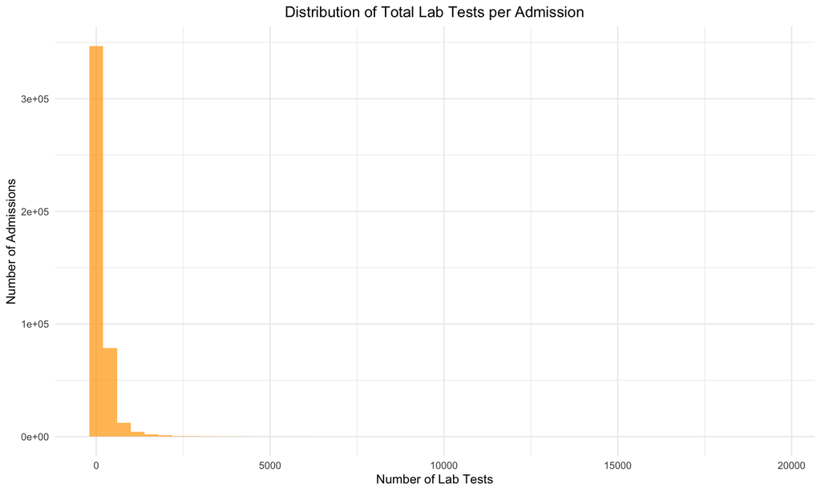

```r
# Simplified Lab Visualization: Lab testing volume per admission
ggplot(labs_per_admission_enhanced, aes(x = total_lab_tests)) +
  geom_histogram(bins = 50, fill = 'orange', alpha = 0.7) +
  labs(title = 'Distribution of Total Lab Tests per Admission',
       x = 'Number of Lab Tests',
       y = 'Number of Admissions') +
  theme_minimal() +
  theme(plot.title = element_text(hjust = 0.5))
```

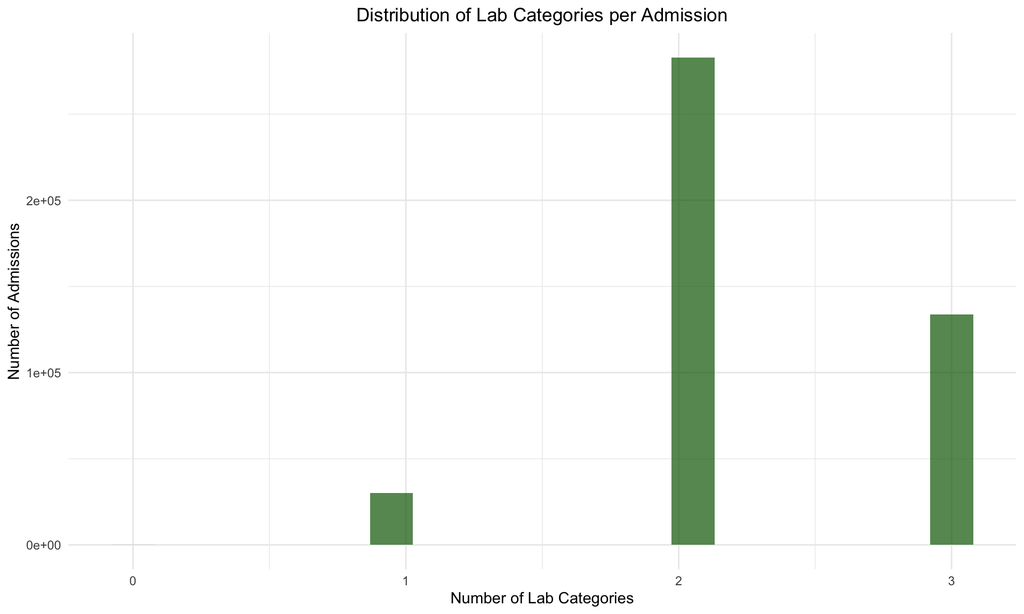

```r
# Lab categories distribution
ggplot(labs_per_admission_enhanced, aes(x = unique_categories)) +
  geom_histogram(bins = 20, fill = 'darkgreen', alpha = 0.7) +
  labs(title = 'Distribution of Lab Categories per Admission',
       x = 'Number of Lab Categories',
       y = 'Number of Admissions') +
  theme_minimal() +
  theme(plot.title = element_text(hjust = 0.5))
```

```r
# Remove existing lab variables before joining (for reproducibility)
analysis_data <- analysis_data %>%
  select(-any_of(c("total_lab_tests", "unique_lab_types", "unique_categories",
                   "chemistry_tests", "hematology_tests", "had_labs", "has_labs")))

# Merge lab data with analysis dataset
analysis_data = analysis_data %>%
  left_join(labs_per_admission_enhanced, by = 'hadm_id') %>%
  mutate(
    total_lab_tests = ifelse(is.na(total_lab_tests), 0, total_lab_tests),
    unique_lab_types = ifelse(is.na(unique_lab_types), 0, unique_lab_types),
    unique_categories = ifelse(is.na(unique_categories), 0, unique_categories),
    chemistry_tests = ifelse(is.na(chemistry_tests), 0, chemistry_tests),
    hematology_tests = ifelse(is.na(hematology_tests), 0, hematology_tests),
    has_labs = ifelse(is.na(has_labs), FALSE, has_labs)
  )

# Lab burden by readmission status
lab_readmission_analysis = analysis_data %>%
  group_by(readmit_30day) %>%
  summarise(
    mean_lab_tests = round(mean(total_lab_tests, na.rm = TRUE), 1),
    median_lab_tests = median(total_lab_tests, na.rm = TRUE),
    q75_lab_tests = quantile(total_lab_tests, 0.75, na.rm = TRUE),
    percent_with_labs = round(mean(has_labs, na.rm = TRUE) * 100, 1),
    mean_unique_types = round(mean(unique_lab_types, na.rm = TRUE), 1),
    .groups = 'drop'
  ) %>%
  mutate(readmission_status = ifelse(readmit_30day == 1, 'Readmitted', 'Not Readmitted'))

nice_table(lab_readmission_analysis[, c('readmission_status', 'mean_lab_tests', 'median_lab_tests',
                                   'q75_lab_tests', 'percent_with_labs', 'mean_unique_types')],
      caption = 'Laboratory Testing Burden by Readmission Status',
      col.names = c('Readmission Status', 'Mean Lab Tests', 'Median Lab Tests',
                   '75th Percentile', '% with Labs', 'Mean Unique Types'))
```

Laboratory Testing Burden by Readmission Status

| Readmission Status | Mean Lab Tests | Median Lab Tests | 75th Percentile | % with Labs | Mean Unique Types |
| --- | --- | --- | --- | --- | --- |
| Not Readmitted | 129.3 | 54 | 139 | 81.5 | 28.8 |
| Readmitted | 172.2 | 80 | 188 | 83.0 | 32.0 |

```r
# Statistical test for difference in lab burden
lab_test_result <- t.test(total_lab_tests ~ readmit_30day, data = analysis_data)
```

**T-test for difference in lab test burden between groups:**  
t = -38.37, p-value = 1.63e-320

The statistically significant difference indicates that readmitted patients undergo more intensive laboratory monitoring during their index admission.

**Lab data coverage:** - Admissions with lab data: 446,711 / 545,847 - Coverage: 81.8%

## 4.5 Procedures Analysis

```r
cat('Procedures dataset contains', nrow(procedures), 'records\n')
```

```
## Procedures dataset contains 859655 records
```

```r
cat('Unique patients:', length(unique(procedures$subject_id)), '\n')
```

```
## Unique patients: 150711
```

```r
cat('Unique admissions:', length(unique(procedures$hadm_id)), '\n')
```

```
## Unique admissions: 287504
```

```r
cat('Unique procedures:', length(unique(procedures$icd_code)), '\n')
```

```
## Unique procedures: 14911
```

```r
# Enhanced procedures analysis with full dictionary integration
procedures_enhanced <- procedures %>%
  left_join(d_icd_procedures, by = c('icd_code' = 'icd_code', 'icd_version' = 'icd_version')) %>%
  mutate(
    # Create meaningful procedure name
    procedure_name = coalesce(long_title, paste("Unknown Procedure", icd_code)),

    # Create procedure categories based on ICD structure and clinical knowledge
    procedure_category = case_when(
      icd_version == 9 ~ case_when(
        substr(icd_code, 1, 2) %in% c("00", "01") ~ "CNS Procedures",
        substr(icd_code, 1, 2) %in% c("02", "03", "04", "05") ~ "Endocrine/Eye/ENT Procedures",
        substr(icd_code, 1, 2) %in% c("06", "07", "08", "09") ~ "Respiratory Procedures",
        substr(icd_code, 1, 2) %in% c("35", "36", "37", "38", "39") ~ "Cardiovascular Procedures",
        substr(icd_code, 1, 2) %in% c("42", "43", "44", "45", "46") ~ "Digestive System Procedures",
        substr(icd_code, 1, 2) %in% c("50", "51", "52", "53", "54") ~ "Urogenital Procedures",
        substr(icd_code, 1, 2) %in% c("77", "78", "79", "80", "81") ~ "Musculoskeletal Procedures",
        substr(icd_code, 1, 2) %in% c("86", "87", "88", "89") ~ "Integumentary/Diagnostic Procedures",
        substr(icd_code, 1, 2) %in% c("92", "93", "94", "95") ~ "Therapeutic Procedures",
        substr(icd_code, 1, 2) %in% c("96", "97", "98", "99") ~ "Miscellaneous Procedures",
        TRUE ~ "Other ICD-9 Procedures"
      ),
      icd_version == 10 ~ case_when(
        substr(icd_code, 1, 1) == "0" ~ case_when(
          substr(icd_code, 2, 2) %in% c("0", "1", "2") ~ "CNS Procedures",
          substr(icd_code, 2, 2) %in% c("3", "4", "5") ~ "Cardiovascular Procedures",
          substr(icd_code, 2, 2) %in% c("6", "7", "8") ~ "Respiratory/Digestive Procedures",
          substr(icd_code, 2, 2) == "9" ~ "Reproductive Procedures",
          TRUE ~ "Other System Procedures"
        ),
        substr(icd_code, 1, 1) == "3" ~ "Administration Procedures",
        substr(icd_code, 1, 1) == "4" ~ "Measurement/Monitoring",
        substr(icd_code, 1, 1) == "5" ~ "Extracorporeal Assistance",
        substr(icd_code, 1, 1) == "6" ~ "Extracorporeal Therapies",
        substr(icd_code, 1, 1) == "7" ~ "Osteopathic Procedures",
        substr(icd_code, 1, 1) == "8" ~ "Other Procedures",
        substr(icd_code, 1, 1) == "9" ~ "Chiropractic Procedures",
        substr(icd_code, 1, 1) == "B" ~ "Imaging Procedures",
        substr(icd_code, 1, 1) == "C" ~ "Nuclear Medicine",
        substr(icd_code, 1, 1) == "D" ~ "Radiation Therapy",
        substr(icd_code, 1, 1) == "F" ~ "Physical Rehabilitation",
        substr(icd_code, 1, 1) == "G" ~ "Mental Health Procedures",
          TRUE ~ "Other ICD-10 Procedures"
      ),
      TRUE ~ "Unknown Version"
    ),
    # High-risk procedure flags based on clinical knowledge
    high_risk_procedure = procedure_category %in% c("CNS Procedures", "Cardiovascular Procedures") |
                         grepl("surgery|transplant|bypass|catheter", procedure_name, ignore.case = TRUE),
    # Invasive vs non-invasive classification
    invasive_procedure = !procedure_category %in% c("Imaging Procedures", "Nuclear Medicine",
                                                   "Measurement/Monitoring", "Physical Rehabilitation") &
                        !grepl("consultation|examination|evaluation", procedure_name, ignore.case = TRUE)
  )

# Check dictionary integration success for procedures
proc_dict_integration_stats <- procedures_enhanced %>%
  summarise(
    total_records = n(),
    with_descriptions = sum(!is.na(long_title)),
    coverage_percent = round(sum(!is.na(long_title)) / n() * 100, 1),
    unique_categories = n_distinct(procedure_category)
  )

cat("Procedure Dictionary Integration Results:\n")
```

```
## Procedure Dictionary Integration Results:
```

```r
cat("Total procedure records:", proc_dict_integration_stats$total_records, "\n")
```

```
## Total procedure records: 859655
```

```r
cat("Records with descriptions:", proc_dict_integration_stats$with_descriptions, "\n")
```

```
## Records with descriptions: 858486
```

```r
cat("Dictionary coverage:", proc_dict_integration_stats$coverage_percent, "%\n")
```

```
## Dictionary coverage: 99.9 %
```

```r
cat("Unique procedure categories:", proc_dict_integration_stats$unique_categories, "\n")
```

```
## Unique procedure categories: 25
```

```r
# Procedure category analysis
proc_category_summary <- procedures_enhanced %>%
  group_by(procedure_category) %>%
  summarise(
    total_procedures = n(),
    unique_codes = n_distinct(icd_code),
    unique_patients = n_distinct(subject_id),
    unique_admissions = n_distinct(hadm_id),
    percent_of_total = round(n() / nrow(procedures_enhanced) * 100, 1),
    .groups = 'drop'
  ) %>%
  arrange(desc(total_procedures))

nice_table(proc_category_summary, caption = 'Procedure Distribution by Clinical Category',
      col.names = c('Clinical Category', 'Total Procedures', 'Unique Codes', 'Unique Patients',
                   'Unique Admissions', '% of Total'))
```

Procedure Distribution by Clinical Category

| Clinical Category | Total Procedures | Unique Codes | Unique Patients | Unique Admissions | % of Total |
| --- | --- | --- | --- | --- | --- |
| Other System Procedures | 184623 | 7711 | 53668 | 80132 | 21.5 |
| Cardiovascular Procedures | 117594 | 1641 | 45231 | 70189 | 13.7 |
| CNS Procedures | 86224 | 994 | 38905 | 51105 | 10.0 |
| Other ICD-9 Procedures | 84155 | 1003 | 36389 | 47907 | 9.8 |
| Integumentary/Diagnostic Procedures | 79111 | 182 | 33746 | 46325 | 9.2 |
| Miscellaneous Procedures | 56028 | 168 | 24071 | 35556 | 6.5 |
| Urogenital Procedures | 34120 | 156 | 14122 | 21239 | 4.0 |
| Musculoskeletal Procedures | 33815 | 339 | 14002 | 17995 | 3.9 |
| Extracorporeal Assistance | 30428 | 38 | 17947 | 23099 | 3.5 |
| Administration Procedures | 30117 | 312 | 17468 | 25358 | 3.5 |
| Digestive System Procedures | 28550 | 170 | 14636 | 19543 | 3.3 |
| Imaging Procedures | 23202 | 532 | 13823 | 16033 | 2.7 |
| Other ICD-10 Procedures | 15801 | 284 | 9658 | 11795 | 1.8 |
| Respiratory/Digestive Procedures | 13947 | 595 | 9787 | 10826 | 1.6 |
| Endocrine/Eye/ENT Procedures | 13205 | 80 | 9054 | 10461 | 1.5 |
| Therapeutic Procedures | 9750 | 70 | 6134 | 7379 | 1.1 |
| Measurement/Monitoring | 8032 | 91 | 5964 | 6652 | 0.9 |
| Mental Health Procedures | 2888 | 9 | 306 | 424 | 0.3 |
| Radiation Therapy | 2292 | 144 | 1187 | 1412 | 0.3 |
| Other Procedures | 2216 | 37 | 2119 | 2168 | 0.3 |
| Respiratory Procedures | 2094 | 67 | 1685 | 1804 | 0.2 |
| Reproductive Procedures | 878 | 260 | 467 | 500 | 0.1 |
| Extracorporeal Therapies | 578 | 23 | 480 | 537 | 0.1 |
| Nuclear Medicine | 4 | 3 | 4 | 4 | 0.0 |
| Physical Rehabilitation | 3 | 2 | 3 | 3 | 0.0 |

```r
# Top procedures with full descriptions
procedure_summary_enhanced <- procedures_enhanced %>%
  group_by(icd_code, icd_version, procedure_name, procedure_category, high_risk_procedure) %>%
  summarise(
    frequency = n(),
    unique_patients = n_distinct(subject_id),
    unique_admissions = n_distinct(hadm_id),
    .groups = 'drop'
  ) %>%
  arrange(desc(frequency))

top_procedures_enhanced <- head(procedure_summary_enhanced, 15) %>%
  mutate(
    # Truncate long descriptions for table readability
    procedure_display = ifelse(nchar(procedure_name) > 50,
                              paste0(substr(procedure_name, 1, 47), "..."),
                              procedure_name),
    risk_level = ifelse(high_risk_procedure, "High Risk", "Standard")
  )

nice_table(top_procedures_enhanced[, c('icd_code', 'icd_version', 'procedure_display', 'procedure_category', 'risk_level', 'frequency')],
      caption = 'Top 15 Most Frequent Procedures with Clinical Categories',
      col.names = c('ICD Code', 'Version', 'Procedure', 'Category', 'Risk Level', 'Frequency'))
```

Top 15 Most Frequent Procedures with Clinical Categories

| ICD Code | Version | Procedure | Category | Risk Level | Frequency |
| --- | --- | --- | --- | --- | --- |
| 3893 | 9 | Venous catheterization, not elsewhere classified | Cardiovascular Procedures | High Risk | 14644 |
| 02HV33Z | 10 | Insertion of Infusion Device into Superior Vena… | CNS Procedures | High Risk | 14353 |
| 8938 | 9 | Other nonoperative respiratory measurements | Integumentary/Diagnostic Procedures | Standard | 10519 |
| 3897 | 9 | Central venous catheter placement with guidance | Cardiovascular Procedures | High Risk | 10347 |
| 8856 | 9 | Coronary arteriography using two catheters | Integumentary/Diagnostic Procedures | High Risk | 9549 |
| 3E0G76Z | 10 | Introduction of Nutritional Substance into Uppe… | Administration Procedures | Standard | 8700 |
| 966 | 9 | Enteral infusion of concentrated nutritional su… | Miscellaneous Procedures | Standard | 8165 |
| 3995 | 9 | Hemodialysis | Cardiovascular Procedures | High Risk | 7808 |
| 0040 | 9 | Procedure on single vessel | CNS Procedures | High Risk | 7581 |
| 9671 | 9 | Continuous invasive mechanical ventilation for … | Miscellaneous Procedures | Standard | 7382 |
| 8952 | 9 | Electrocardiogram | Integumentary/Diagnostic Procedures | Standard | 6828 |
| 5491 | 9 | Percutaneous abdominal drainage | Urogenital Procedures | Standard | 6549 |
| 9604 | 9 | Insertion of endotracheal tube | Miscellaneous Procedures | Standard | 6490 |
| 0BH17EZ | 10 | Insertion of Endotracheal Airway into Trachea, … | Other System Procedures | Standard | 6197 |
| 3722 | 9 | Left heart cardiac catheterization | Cardiovascular Procedures | High Risk | 6119 |

```r
# Enhanced procedures per admission analysis
procedures_per_admission_enhanced = procedures_enhanced %>%
  group_by(hadm_id) %>%
  summarise(
    procedure_count = n(),
    unique_procedures = n_distinct(icd_code),
    unique_categories = n_distinct(procedure_category),
    high_risk_procedure_count = sum(high_risk_procedure),
    invasive_procedure_count = sum(invasive_procedure),
    has_cardiovascular_proc = any(procedure_category == "Cardiovascular Procedures"),
    has_respiratory_proc = any(procedure_category == "Respiratory Procedures" | procedure_category == "Respiratory/Digestive Procedures"),
    has_cns_proc = any(procedure_category == "CNS Procedures"),
    has_imaging = any(procedure_category == "Imaging Procedures"),
    .groups = 'drop'
  )

procedure_burden_enhanced_stats = procedures_per_admission_enhanced %>%
  summarise(
    mean_procedures = round(mean(procedure_count), 1),
    median_procedures = round(median(procedure_count), 1),
    max_procedures = max(procedure_count),
    q75_procedures = round(quantile(procedure_count, 0.75), 1),
    mean_categories = round(mean(unique_categories), 1),
    mean_high_risk = round(mean(high_risk_procedure_count), 1),
    mean_invasive = round(mean(invasive_procedure_count), 1)
  )

procedure_burden_enhanced_table <- data.frame(
  Metric = c('Mean Procedures per Admission', 'Median Procedures per Admission',
             'Max Procedures per Admission', '75th Percentile Procedures',
             'Mean Procedure Categories', 'Mean High-Risk Procedures', 'Mean Invasive Procedures'),
  Value = c(procedure_burden_enhanced_stats$mean_procedures,
            procedure_burden_enhanced_stats$median_procedures,
            procedure_burden_enhanced_stats$max_procedures,
            procedure_burden_enhanced_stats$q75_procedures,
            procedure_burden_enhanced_stats$mean_categories,
            procedure_burden_enhanced_stats$mean_high_risk,
            procedure_burden_enhanced_stats$mean_invasive)
)

nice_table(procedure_burden_enhanced_table, caption = 'Enhanced Procedure Burden per Admission')
```

Enhanced Procedure Burden per Admission

| Metric | Value |
| --- | --- |
| Mean Procedures per Admission | 3.0 |
| Median Procedures per Admission | 2.0 |
| Max Procedures per Admission | 41.0 |
| 75th Percentile Procedures | 4.0 |
| Mean Procedure Categories | 1.8 |
| Mean High-Risk Procedures | 0.8 |
| Mean Invasive Procedures | 2.9 |

```r
# Remove existing procedure variables before joining (for reproducibility)
analysis_data <- analysis_data %>%
  select(-any_of(c("procedure_count", "unique_procedures", "unique_categories",
                   "high_risk_procedure_count", "invasive_procedure_count",
                   "has_cardiovascular_proc", "has_respiratory_proc", "has_cns_proc", "has_imaging")))

# Merge enhanced procedure data with analysis dataset
analysis_data = analysis_data %>%
  left_join(procedures_per_admission_enhanced, by = 'hadm_id') %>%
  mutate(
    procedure_count = ifelse(is.na(procedure_count), 0, procedure_count),
    unique_procedures = ifelse(is.na(unique_procedures), 0, unique_procedures),
    unique_categories = ifelse(is.na(unique_categories), 0, unique_categories),
    high_risk_procedure_count = ifelse(is.na(high_risk_procedure_count), 0, high_risk_procedure_count),
    invasive_procedure_count = ifelse(is.na(invasive_procedure_count), 0, invasive_procedure_count),
    has_cardiovascular_proc = ifelse(is.na(has_cardiovascular_proc), FALSE, has_cardiovascular_proc),
    has_respiratory_proc = ifelse(is.na(has_respiratory_proc), FALSE, has_respiratory_proc),
    has_cns_proc = ifelse(is.na(has_cns_proc), FALSE, has_cns_proc),
    has_imaging = ifelse(is.na(has_imaging), FALSE, has_imaging)
  )

# High-risk procedure analysis and readmission
high_risk_proc_analysis <- analysis_data %>%
  summarise(
    cv_proc_readmit_rate = round(mean(readmit_30day[has_cardiovascular_proc == TRUE], na.rm = TRUE) * 100, 1),
    respiratory_proc_readmit_rate = round(mean(readmit_30day[has_respiratory_proc == TRUE], na.rm = TRUE) * 100, 1),
    cns_proc_readmit_rate = round(mean(readmit_30day[has_cns_proc == TRUE], na.rm = TRUE) * 100, 1),
    imaging_readmit_rate = round(mean(readmit_30day[has_imaging == TRUE], na.rm = TRUE) * 100, 1),
    overall_readmit_rate = round(mean(readmit_30day, na.rm = TRUE) * 100, 1)
  )

proc_risk_table <- data.frame(
  Procedure_Category = c('Cardiovascular', 'Respiratory', 'CNS', 'Imaging', 'Overall'),
  Readmission_Rate = c(high_risk_proc_analysis$cv_proc_readmit_rate,
                       high_risk_proc_analysis$respiratory_proc_readmit_rate,
                       high_risk_proc_analysis$cns_proc_readmit_rate,
                       high_risk_proc_analysis$imaging_readmit_rate,
                       high_risk_proc_analysis$overall_readmit_rate)
)

nice_table(proc_risk_table, caption = 'Readmission Rates by Procedure Categories',
      col.names = c('Procedure Category', 'Readmission Rate (%)'))
```

Readmission Rates by Procedure Categories

| Procedure Category | Readmission Rate (%) |
| --- | --- |
| Cardiovascular | 22.3 |
| Respiratory | 21.1 |
| CNS | 20.3 |
| Imaging | 19.7 |
| Overall | 20.0 |

```r
# Enhanced procedure burden by readmission status
procedure_readmission_enhanced = analysis_data %>%
  group_by(readmit_30day) %>%
  summarise(
    mean_procedures = round(mean(procedure_count, na.rm = TRUE), 2),
    median_procedures = median(procedure_count, na.rm = TRUE),
    mean_categories = round(mean(unique_categories, na.rm = TRUE), 2),
    mean_high_risk = round(mean(high_risk_procedure_count, na.rm = TRUE), 2),
    mean_invasive = round(mean(invasive_procedure_count, na.rm = TRUE), 2),
    q75_procedures = quantile(procedure_count, 0.75, na.rm = TRUE),
    .groups = 'drop'
  ) %>%
  mutate(readmission_status = ifelse(readmit_30day == 1, 'Readmitted', 'Not Readmitted'))

nice_table(procedure_readmission_enhanced[, c('readmission_status', 'mean_procedures', 'median_procedures', 'mean_categories', 'mean_high_risk', 'mean_invasive')],
      caption = 'Enhanced Procedure Burden by Readmission Status',
      col.names = c('Readmission Status', 'Mean Procedures', 'Median Procedures', 'Mean Categories', 'Mean High-Risk', 'Mean Invasive'))
```

Enhanced Procedure Burden by Readmission Status

| Readmission Status | Mean Procedures | Median Procedures | Mean Categories | Mean High-Risk | Mean Invasive |
| --- | --- | --- | --- | --- | --- |
| Not Readmitted | 1.56 | 1 | 0.92 | 0.41 | 1.50 |
| Readmitted | 1.62 | 1 | 0.97 | 0.43 | 1.57 |

## 4.5 Key Visualizations

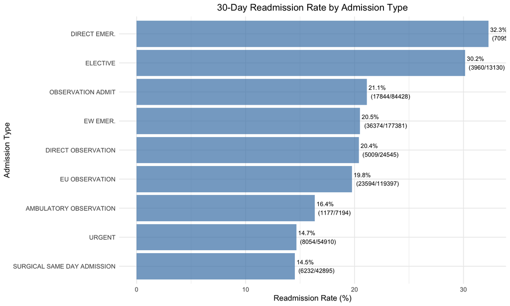

Key relationships with readmission outcomes

```r
# Readmission rate by admission type
admission_type_summary = analysis_data %>%
  group_by(admission_type) %>%
  summarise(
    total = n(),
    readmissions = sum(readmit_30day),
    rate = (readmissions / total) * 100,
    .groups = 'drop'
  ) %>%
  filter(total >= 10) # Only show types with sufficient sample size

ggplot(admission_type_summary, aes(x = reorder(admission_type, rate), y = rate)) +
  geom_col(fill = 'steelblue', alpha = 0.7) +
  geom_text(aes(label = paste0(round(rate, 1), '%\n(', readmissions, '/', total, ')')),
            hjust = -0.1, size = 3) +
  coord_flip() +
  labs(title = '30-Day Readmission Rate by Admission Type',
       x = 'Admission Type',
       y = 'Readmission Rate (%)') +
  theme_minimal() +
  theme(plot.title = element_text(hjust = 0.5))
```

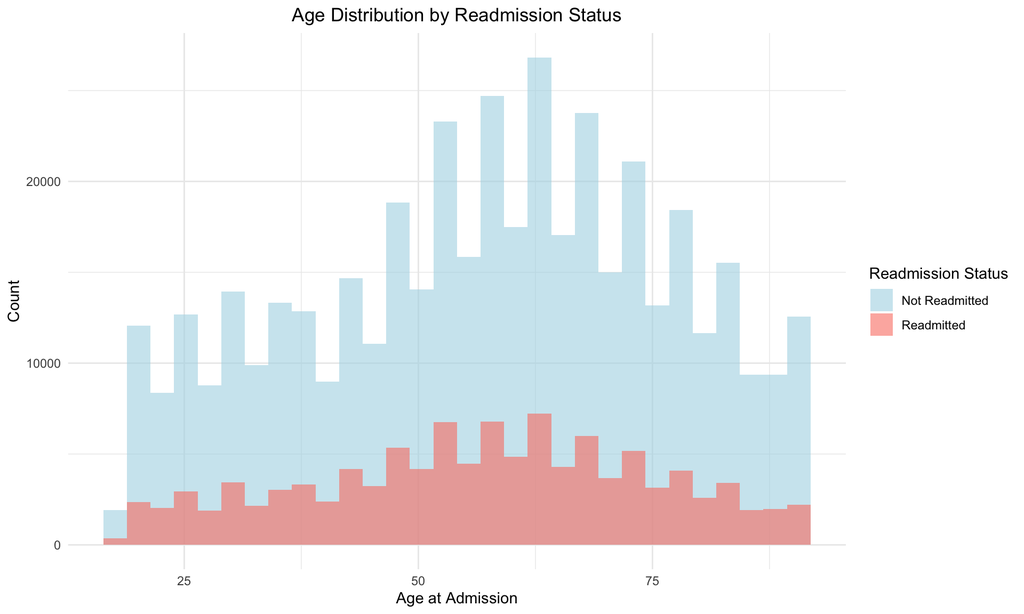

Key relationships with readmission outcomes

```r
# Age distribution by readmission status
ggplot(analysis_data, aes(x = age_at_adm, fill = factor(readmit_30day))) +
  geom_histogram(position = 'identity', alpha = 0.6, bins = 30) +
  scale_fill_manual(values = c('0' = 'lightblue', '1' = 'salmon'),
                    labels = c('0' = 'Not Readmitted', '1' = 'Readmitted'),
                    name = 'Readmission Status') +
  labs(title = 'Age Distribution by Readmission Status',
       x = 'Age at Admission',
       y = 'Count') +
  theme_minimal() +
  theme(plot.title = element_text(hjust = 0.5))
```

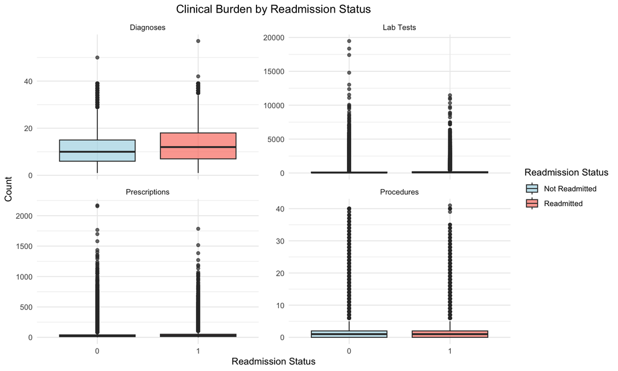

Key relationships with readmission outcomes

```r
# Clinical burden comparison
clinical_burden_plot_data <- analysis_data %>%
  select(readmit_30day, total_diagnoses, medication_count, procedure_count, total_lab_tests) %>%
  pivot_longer(cols = c(total_diagnoses, medication_count, procedure_count, total_lab_tests),
               names_to = 'clinical_measure',
               values_to = 'count') %>%
  mutate(
    clinical_measure = case_when(
      clinical_measure == 'total_diagnoses' ~ 'Diagnoses',
      clinical_measure == 'medication_count' ~ 'Prescriptions',
      clinical_measure == 'procedure_count' ~ 'Procedures',
      clinical_measure == 'total_lab_tests' ~ 'Lab Tests'
    ),
    readmission_status = ifelse(readmit_30day == 1, 'Readmitted', 'Not Readmitted')
  )

ggplot(clinical_burden_plot_data, aes(x = factor(readmit_30day), y = count, fill = factor(readmit_30day))) +
  geom_boxplot(alpha = 0.7) +
  facet_wrap(~ clinical_measure, scales = 'free_y') +
  scale_fill_manual(values = c('0' = 'lightblue', '1' = 'salmon'),
                    labels = c('0' = 'Not Readmitted', '1' = 'Readmitted'),
                    name = 'Readmission Status') +
  labs(title = 'Clinical Burden by Readmission Status',
       x = 'Readmission Status',
       y = 'Count') +
  theme_minimal() +
  theme(plot.title = element_text(hjust = 0.5))
```

# 5. Data Quality Assessment

## 5.1 Data Completeness Analysis

```r
# Assess missing data patterns for key variables
key_vars <- c('subject_id', 'hadm_id', 'readmit_30day', 'age_at_adm', 'gender',
              'race', 'insurance', 'admission_type', 'los_days', 'total_diagnoses',
              'unique_diagnosis_categories', 'medication_count', 'unique_categories',
              'procedure_count', 'total_lab_tests', 'unique_lab_types')

completeness_summary <- analysis_data %>%
  select(all_of(key_vars)) %>%
  summarise(across(everything(), ~ sum(!is.na(.)))) %>%
  pivot_longer(everything(), names_to = 'variable', values_to = 'complete_count') %>%
  mutate(
    total_cases = nrow(analysis_data),
    completeness_percent = round(complete_count / total_cases * 100, 1),
    missing_count = total_cases - complete_count,
    missing_percent = round(missing_count / total_cases * 100, 1)
  ) %>%
  arrange(desc(completeness_percent))

nice_table(completeness_summary[, c('variable', 'complete_count', 'missing_count', 'completeness_percent', 'missing_percent')],
      caption = 'Data Completeness Summary for Key Variables',
      col.names = c('Variable', 'Complete Count', 'Missing Count', 'Completeness %', 'Missing %'))
```

Data Completeness Summary for Key Variables

| Variable | Complete Count | Missing Count | Completeness % | Missing % |
| --- | --- | --- | --- | --- |
| subject_id | 545847 | 0 | 100.0 | 0.0 |
| hadm_id | 545847 | 0 | 100.0 | 0.0 |
| readmit_30day | 545847 | 0 | 100.0 | 0.0 |
| age_at_adm | 545847 | 0 | 100.0 | 0.0 |
| gender | 545847 | 0 | 100.0 | 0.0 |
| race | 545847 | 0 | 100.0 | 0.0 |
| insurance | 545847 | 0 | 100.0 | 0.0 |
| admission_type | 545847 | 0 | 100.0 | 0.0 |
| los_days | 545847 | 0 | 100.0 | 0.0 |
| medication_count | 545847 | 0 | 100.0 | 0.0 |
| unique_categories | 545847 | 0 | 100.0 | 0.0 |
| procedure_count | 545847 | 0 | 100.0 | 0.0 |
| total_lab_tests | 545847 | 0 | 100.0 | 0.0 |
| unique_lab_types | 545847 | 0 | 100.0 | 0.0 |
| total_diagnoses | 545316 | 531 | 99.9 | 0.1 |
| unique_diagnosis_categories | 545316 | 531 | 99.9 | 0.1 |

### Final Analysis Dataset Summary

**Total admissions in analysis dataset:** 545,847  
**Patients with readmissions:** 109,339  
**Overall readmission rate:** 20.03%

**Coverage rates:** - **Diagnoses data:** 99.9% - **Prescriptions data:** 84.9% - **Procedures data:** 52.7% - **Lab data:** 81.8% - **High-risk conditions identified:** 36%

The dataset demonstrates high completeness for administrative variables and moderate coverage for clinical variables, with strong representation across all major data domains.

# 6. Feature Engineering

## 6.1 Comorbidity Indices

```r
# Charlson Comorbidity Index calculation -- Healthcare standard method
# Based on ICD-9 and ICD-10 codes

# Charlson Comorbidity Index with proper NA handling
charlson_components <- analysis_data %>%
  mutate(
    # Cardiovascular conditions
    charlson_mi = ifelse(!is.na(primary_diagnosis_name) & grepl("myocardial infarction|acute mi", primary_diagnosis_name, ignore.case = TRUE), 1, 0),
    charlson_chf = ifelse(has_heart_failure, 1, 0),
    charlson_pvd = ifelse(!is.na(primary_diagnosis_name) & grepl("peripheral vascular|arterial disease", primary_diagnosis_name, ignore.case = TRUE), 1, 0),
    charlson_cvd = ifelse(!is.na(primary_diagnosis_name) & grepl("cerebrovascular|stroke|tia", primary_diagnosis_name, ignore.case = TRUE), 1, 0),

    # Pulmonary conditions
    charlson_copd = ifelse(has_copd, 1, 0),

    # Metabolic conditions
    charlson_diabetes = ifelse(has_diabetes, 1, 0),
    charlson_diabetes_comp = ifelse(!is.na(primary_diagnosis_name) & grepl("diabetes.*complication|diabetic.*retinopathy|diabetic.*nephropathy", primary_diagnosis_name, ignore.case = TRUE), 1, 0),

    # Renal conditions
    charlson_renal = ifelse(!is.na(primary_diagnosis_name) & grepl("chronic kidney|renal failure|chronic renal", primary_diagnosis_name, ignore.case = TRUE), 1, 0),

    # Liver conditions
    charlson_liver_mild = ifelse(!is.na(primary_diagnosis_name) & grepl("hepatitis|liver disease", primary_diagnosis_name, ignore.case = TRUE) &
                                !grepl("severe|cirrhosis|failure", primary_diagnosis_name, ignore.case = TRUE), 1, 0),
    charlson_liver_severe = ifelse(!is.na(primary_diagnosis_name) & grepl("liver.*severe|cirrhosis|liver.*failure", primary_diagnosis_name, ignore.case = TRUE), 1, 0),

    # Cancer conditions
    charlson_cancer = ifelse(!is.na(primary_diagnosis_category) & primary_diagnosis_category == "Neoplasms" &
                           (!is.na(primary_diagnosis_name) & !grepl("metastatic|metastasis", primary_diagnosis_name, ignore.case = TRUE)), 1, 0),
    charlson_cancer_mets = ifelse(!is.na(primary_diagnosis_name) & grepl("metastatic|metastasis", primary_diagnosis_name, ignore.case = TRUE), 1, 0),

    # Other conditions
    charlson_dementia = ifelse(!is.na(primary_diagnosis_name) & grepl("dementia|alzheimer", primary_diagnosis_name, ignore.case = TRUE), 1, 0),
    charlson_paralysis = ifelse(!is.na(primary_diagnosis_name) & grepl("paralysis|hemiplegia|paraplegia", primary_diagnosis_name, ignore.case = TRUE), 1, 0),
    charlson_peptic = ifelse(!is.na(primary_diagnosis_name) & grepl("peptic ulcer|gastric ulcer", primary_diagnosis_name, ignore.case = TRUE), 1, 0),
    charlson_rheum = ifelse(!is.na(primary_diagnosis_name) & grepl("rheumatoid|lupus|connective tissue", primary_diagnosis_name, ignore.case = TRUE), 1, 0),
    charlson_aids = ifelse(!is.na(primary_diagnosis_name) & grepl("hiv|aids", primary_diagnosis_name, ignore.case = TRUE), 1, 0)
  ) %>%
  mutate(
    # Calculate weighted Charlson score
    charlson_score =
      (charlson_mi * 1) +
      (charlson_chf * 1) +
      (charlson_pvd * 1) +
      (charlson_cvd * 1) +
      (charlson_copd * 1) +
      (charlson_diabetes * 1) +
      (charlson_diabetes_comp * 2) +
      (charlson_renal * 2) +
      (charlson_liver_mild * 1) +
      (charlson_liver_severe * 3) +
      (charlson_cancer * 2) +
      (charlson_cancer_mets * 6) +
      (charlson_dementia * 1) +
      (charlson_paralysis * 2) +
      (charlson_peptic * 1) +
      (charlson_rheum * 1) +
      (charlson_aids * 6),

    # Create risk categories
    charlson_category = case_when(
      charlson_score == 0 ~ "Low Risk (0)",
      charlson_score %in% 1:2 ~ "Moderate Risk (1-2)",
      charlson_score %in% 3:4 ~ "High Risk (3-4)",
      charlson_score >= 5 ~ "Very High Risk (5+)"
    )
  )

charlson_stats = charlson_components %>%
  summarise(
    mean_charlson = round(mean(charlson_score, na.rm = TRUE), 2),
    median_charlson = median(charlson_score, na.rm = TRUE),
    max_charlson = max(charlson_score, na.rm = TRUE),
    q75_charlson = quantile(charlson_score, 0.75, na.rm = TRUE),
    percent_high_risk = round(mean(charlson_score >= 3, na.rm = TRUE) * 100, 1)
  )

charlson_summary_table = data.frame(
  Metric = c('Mean Charlson Score', 'Median Charlson Score', 'Max Charlson Score',
             '75th Percentile Charlson Score', '% High Risk (Score >=3)'),
  Value = c(charlson_stats$mean_charlson, charlson_stats$median_charlson,
            charlson_stats$max_charlson, charlson_stats$q75_charlson,
            charlson_stats$percent_high_risk)
)

nice_table(charlson_summary_table, caption = 'Charlson Comorbidity Index Summary')
```

Charlson Comorbidity Index Summary

| Metric | Value |
| --- | --- |
| Mean Charlson Score | 0.7 |
| Median Charlson Score | 0.0 |
| Max Charlson Score | 9.0 |
| 75th Percentile Charlson Score | 1.0 |
| % High Risk (Score >=3) | 5.4 |

```r
# Charlson Readmission Analysis
charlson_readmission = charlson_components %>%
  group_by(charlson_category) %>%
  summarise(
    total_cases = n(),
    readmissions = sum(readmit_30day, na.rm = TRUE),
    readmission_rate = round((readmissions / total_cases) * 100, 2),
    .groups = 'drop'
  ) %>%
  arrange(desc(readmission_rate))

nice_table(charlson_readmission, caption = 'Readmission Rates by Charlson Comorbidity Category',
      col.names = c('Charlson Category', 'Total Cases', 'Readmissions', 'Readmission Rate (%)'))
```

Readmission Rates by Charlson Comorbidity Category

| Charlson Category | Total Cases | Readmissions | Readmission Rate (%) |
| --- | --- | --- | --- |
| Very High Risk (5+) | 1632 | 465 | 28.49 |
| High Risk (3-4) | 27641 | 7041 | 25.47 |
| NA | 531 | 135 | 25.42 |
| Moderate Risk (1-2) | 216946 | 45349 | 20.90 |
| Low Risk (0) | 299097 | 56349 | 18.84 |

```r
# Update analysis_data with Charlson features
analysis_data = charlson_components
```

**Note on Charlson Comorbidity Index Implementation:** The Charlson index in this analysis is based on primary diagnosis codes only, which likely underestimates the true comorbidity burden of the patient population (mean score = 0.7 vs. typical hospital population means of 2-4). A comprehensive implementation would require analyzing all diagnosis codes per admission rather than only the primary diagnosis. However, the simplified version still demonstrates directional validity, with readmission rates increasing monotonically across Charlson risk categories. This limitation is acknowledged as a tradeoff between computational feasibility and clinical comprehensiveness, and the model incorporates additional comorbidity signals through other features (diagnostic complexity scores, multi-system involvement indicators, and high-risk condition flags).

## 6.2 Healthcare Utilization Features

```r
# Create healthcare utilization intensity features
utilization_features = analysis_data %>%
  mutate(
    # Length of stay categories
    los_category = case_when(
      los_days < 3 ~ 'Short Stay (<3 days)',
      los_days >= 3 & los_days <= 7 ~ 'Medium Stay (3-7 days)',
      los_days > 7 ~ 'Long Stay (>7 days)',
    ),

    # Clinical complexity indicators
    total_clinical_events = total_diagnoses + medication_count + procedure_count + total_lab_tests,

    # Polypharmacy risk categories
    polypharmacy_risk = case_when(
      medication_count == 0 ~ 'No Medications',
      medication_count <= 5 ~ 'Low Polypharmacy (1-5)',
      medication_count <= 10 ~ 'Moderate Polypharmacy (6-10)',
      medication_count <= 20 ~ 'High Polypharmacy (11-20)',
      medication_count > 20 ~ 'Very High Polypharmacy (>20)'
    ),

    # Laboratory testing intensity
    lab_testing_intensity = case_when(
      total_lab_tests == 0 ~ 'No Labs',
      total_lab_tests <= 10 ~ 'Low Testing (1-10)',
      total_lab_tests <= 50 ~ 'Moderate Testing (11-50)',
      total_lab_tests <= 100 ~ 'High Testing (51-100)',
      total_lab_tests > 100 ~ 'Intensive Testing (>100)'
    ),

    # Procedure complexity
    procedure_complexity = case_when(
      procedure_count == 0 ~ 'No Procedures',
      procedure_count <= 2 ~ 'Simple (1-2)',
      procedure_count <= 5 ~ 'Moderate (3-5)',
      procedure_count > 5 ~ 'Complex (>5)'
    ),

    # Age-adjusted risk
    age_risk_category = case_when(
      age_at_adm < 30 ~ 'Young Adult(<30)',
      age_at_adm < 50 ~ 'Middle Age (30-49)',
      age_at_adm < 65 ~ 'Older Adult (50-64)',
      age_at_adm < 80 ~ 'Elderly (65-79)',
      age_at_adm >= 80 ~ 'Very Elderly (80+)'
    ),

    # High-risk combinations
    high_risk_combination = case_when(
      age_at_adm >= 65 & charlson_score >= 3 ~ 'Elderly + High Comorbidity',
      age_at_adm >= 65 & medication_count > 10 ~ 'Elderly + Polypharmacy',
      charlson_score >= 3 & medication_count > 10 ~ 'High Comorbidity + Polypharmacy',
      age_at_adm >= 80 ~ 'Very Elderly Only',
      charlson_score >= 5 ~ 'Very High Comorbidity Only',
      medication_count > 20 ~ 'Very High Polypharmacy Only',
      TRUE ~ 'Standard Risk'
    )
  )

# Utilization feature statistics
utilization_stats = utilization_features %>%
  summarise(
    mean_clinical_events = round(mean(total_clinical_events, na.rm = TRUE), 1),
    median_clinical_events = median(total_clinical_events, na.rm = TRUE),
    high_polypharmacy_percent = round(mean(medication_count > 10, na.rm = TRUE) * 100, 1),
    intensive_testing_percent = round(mean(total_lab_tests > 100, na.rm = TRUE) * 100, 1),
    high_risk_combo_percent = round(mean(high_risk_combination != 'Standard Risk', na.rm = TRUE) * 100, 1)
  )

utilization_summary_table = data.frame(
  Metric = c('Mean Total Clinical Events', 'Median Total Clinical Events',
             '% with High Polypharmacy (>10 meds)', '% with Intensive Lab Testing (>100 tests)',
             '% with High-Risk Combinations'),
  Value = c(utilization_stats$mean_clinical_events, utilization_stats$median_clinical_events,
            utilization_stats$high_polypharmacy_percent, utilization_stats$intensive_testing_percent,
            utilization_stats$high_risk_combo_percent)
)

nice_table(utilization_summary_table, caption = 'Healthcare Utilization Feature Summary')
```

Healthcare Utilization Feature Summary

| Metric | Value |
| --- | --- |
| Mean Total Clinical Events | 188.5 |
| Median Total Clinical Events | 95.0 |
| % with High Polypharmacy (>10 meds) | 78.5 |
| % with Intensive Lab Testing (>100 tests) | 35.3 |
| % with High-Risk Combinations | 65.9 |

```r
# High-risk combination analysis
risk_combo_analysis = utilization_features %>%
  group_by(high_risk_combination) %>%
  summarise(
    total_cases = n(),
    readmissions = sum(readmit_30day, na.rm = TRUE),
    readmission_rate = round((readmissions / total_cases) * 100, 2),
    .groups = 'drop'
  ) %>%
  arrange(desc(readmission_rate))

nice_table(risk_combo_analysis, caption = 'Readmission Rates by High-Risk Combinations',
      col.names = c('Risk Combination', 'Total Cases', 'Readmissions', 'Readmission Rate (%)'))
```

Readmission Rates by High-Risk Combinations

| Risk Combination | Total Cases | Readmissions | Readmission Rate (%) |
| --- | --- | --- | --- |
| High Comorbidity + Polypharmacy | 12775 | 3719 | 29.11 |
| Very High Polypharmacy Only | 158350 | 38332 | 24.21 |
| Elderly + High Comorbidity | 15899 | 3663 | 23.04 |
| Elderly + Polypharmacy | 164667 | 31334 | 19.03 |
| Standard Risk | 185985 | 31266 | 16.81 |
| Very High Comorbidity Only | 34 | 5 | 14.71 |
| Very Elderly Only | 8137 | 1020 | 12.54 |

```r
# Update analysis_data with utilization features
analysis_data = utilization_features
```

## 6.3 Medication Risk Features

```r
# Create advanced medication risk features based on validated drug categories
medication_risk_features = analysis_data %>%
  mutate(
    # Drug interaction risk flags
    anticoagulant_risk = ifelse(grepl('Anticoagulants', paste(unique_categories, collapse = ' ')), 1, 0),
    cns_depression_risk = ifelse(grepl('CNS Medications', paste(unique_categories, collapse = ' ')), 1, 0),

    # Medication burden indicators
    medication_burden_score = case_when(
      medication_count == 0 ~ 0,
      medication_count <= 5 ~ 1,
      medication_count <= 10 ~ 2,
      medication_count <= 15 ~ 3,
      medication_count <= 20 ~ 4,
      medication_count > 20 ~ 5
    ),

    # Therapeutic category diversity
    therapeutic_diversity = unique_categories,
    high_therapeutic_diversity = ifelse(unique_categories > 5, 1, 0),

    # High-risk medicatino patterns
    pain_management_intensive = ifelse(grepl('Pain Management', paste(unique_categories, collapse = ' ')) & medication_count >= 10, 1, 0),

    cardiovascular_complex = ifelse(grepl('Cardiovascular', paste(unique_categories, collapse = ' ')) &
                                      grepl('Anticoagulants', paste(unique_categories, collapse = ' ')), 1, 0),

    # Medication appropriateness indicators
    elderly_polypharmacy = ifelse(age_at_adm >= 65 & medication_count >= 10, 1, 0),
    extreme_polypharmacy = ifelse(medication_count >= 20, 1, 0),

    # Create medicatino risk score (composite)
    medication_risk_score =
      (medication_burden_score * 1) +
      (high_therapeutic_diversity * 1) +
      (anticoagulant_risk * 2) +
      (cns_depression_risk * 1) +
      (elderly_polypharmacy * 2) +
      (extreme_polypharmacy * 3) +
      (pain_management_intensive * 2) +
      (cardiovascular_complex * 2),

    # Medication risk categories
    medication_risk_category = case_when(
      medication_risk_score == 0 ~ 'Minimal Risk (0)',
      medication_risk_score %in% 1:3 ~ 'Low Risk (1-3)',
      medication_risk_score %in% 4:6 ~ 'Moderate Risk (4-6)',
      medication_risk_score %in% 7:9 ~ 'High Risk (7-9)',
      medication_risk_score >= 10 ~ 'Very High Risk (10+)'
    )
  )

# Medication risk statistics
med_risk_stats = medication_risk_features %>%
  summarise(
    mean_risk_score = round(mean(medication_risk_score, na.rm = TRUE), 2),
    median_risk_score = median(medication_risk_score, na.rm = TRUE),
    high_risk_percent = round(mean(medication_risk_score >= 7, na.rm = TRUE) * 100, 1),
    elderly_polypharmacy_percent = round(mean(elderly_polypharmacy == 1, na.rm = TRUE) * 100, 1)
  )

med_risk_summary_table = data.frame(
  Metric = c('Mean Medication Risk Score', 'Median Medication Risk Score',
             '% High or Very High Risk (Score >=7)', '% with Elderly Polypharmacy'),
  Value = c(med_risk_stats$mean_risk_score, med_risk_stats$median_risk_score,
            med_risk_stats$high_risk_percent, med_risk_stats$elderly_polypharmacy_percent)
)

nice_table(med_risk_summary_table, caption = 'Medication Risk Feature Summary')
```

Medication Risk Feature Summary

| Metric | Value |
| --- | --- |
| Mean Medication Risk Score | 6.15 |
| Median Medication Risk Score | 8.00 |
| % High or Very High Risk (Score >=7) | 58.70 |
| % with Elderly Polypharmacy | 33.40 |

```r
# Medication risk by readmission
med_risk_readmission = medication_risk_features %>%
  group_by(medication_risk_category) %>%
  summarise(
    total_cases = n(),
    readmissions = sum(readmit_30day, na.rm = TRUE),
    readmission_rate = round((readmissions / total_cases) * 100, 2),
    .groups = 'drop'
  ) %>%
  arrange(desc(readmission_rate))

nice_table(med_risk_readmission, caption = 'Readmission Rates by Medication Risk Category',
      col.names = c('Medication Risk Category', 'Total Cases', 'Readmissions', 'Readmission Rate (%)'))
```

Readmission Rates by Medication Risk Category

| Medication Risk Category | Total Cases | Readmissions | Readmission Rate (%) |
| --- | --- | --- | --- |
| High Risk (7-9) | 182415 | 43876 | 24.05 |
| Minimal Risk (0) | 82617 | 18463 | 22.35 |
| Very High Risk (10+) | 137834 | 28571 | 20.73 |
| Moderate Risk (4-6) | 71404 | 10378 | 14.53 |
| Low Risk (1-3) | 71577 | 8051 | 11.25 |

```r
# Update analysis_data with medication risk features
analysis_data = medication_risk_features
```

## 6.4 Clinical Complexity Features

```r
# Create comprehensive clinical complexity indicators

complexity_features <- analysis_data %>%
  mutate(
    # Diagnostic complexity
    diagnostic_complexity = case_when(
      total_diagnoses <= 5 ~ "Simple (≤5 diagnoses)",
      total_diagnoses <= 10 ~ "Moderate (6-10 diagnoses)",
      total_diagnoses <= 15 ~ "Complex (11-15 diagnoses)",
      total_diagnoses > 15 ~ "Very Complex (>15 diagnoses)"
    ),

    # Multi-system involvement
    multi_system_score = unique_diagnosis_categories,
    multi_system_complexity = ifelse(unique_diagnosis_categories >= 4, 1, 0),

    # Procedure-based complexity
    procedural_complexity = case_when(
      procedure_count == 0 ~ "No Procedures",
      procedure_count <= 2 & high_risk_procedure_count == 0 ~ "Simple Procedures",
      procedure_count <= 5 & high_risk_procedure_count <= 1 ~ "Moderate Complexity",
      high_risk_procedure_count >= 2 ~ "High-Risk Procedures",
      procedure_count > 5 ~ "High Volume Procedures"
    ),

    # Laboratory monitoring intensity
    lab_monitoring_complexity = case_when(
      total_lab_tests <= 10 ~ "Minimal Monitoring",
      total_lab_tests <= 30 ~ "Standard Monitoring",
      total_lab_tests <= 75 ~ "Intensive Monitoring",
      total_lab_tests > 75 ~ "Critical Monitoring"
    ),

    # Overall clinical complexity score
    clinical_complexity_score =
      (case_when(
        total_diagnoses <= 5 ~ 1,
        total_diagnoses <= 10 ~ 2,
        total_diagnoses <= 15 ~ 3,
        total_diagnoses > 15 ~ 4
      )) +
      (case_when(
        unique_diagnosis_categories <= 2 ~ 1,
        unique_diagnosis_categories <= 4 ~ 2,
        unique_diagnosis_categories > 4 ~ 3
      )) +
      (case_when(
        procedure_count == 0 ~ 0,
        procedure_count <= 2 ~ 1,
        procedure_count <= 5 ~ 2,
        procedure_count > 5 ~ 3
      )) +
      (case_when(
        total_lab_tests <= 30 ~ 1,
        total_lab_tests <= 75 ~ 2,
        total_lab_tests > 75 ~ 3
      )) +
      (high_risk_procedure_count * 2) +
      (charlson_score),

    # Clinical complexity categories
    clinical_complexity_category = case_when(
      clinical_complexity_score <= 5 ~ "Low Complexity",
      clinical_complexity_score <= 10 ~ "Moderate Complexity",
      clinical_complexity_score <= 15 ~ "High Complexity",
      clinical_complexity_score > 15 ~ "Very High Complexity"
    ),

    # Specific high-risk clinical patterns
    icu_intensive_pattern = ifelse(total_lab_tests > 75 & medication_count > 15 & procedure_count > 3, 1, 0),
    chronic_complex_pattern = ifelse(charlson_score >= 3 & unique_diagnosis_categories >= 4, 1, 0),
    acute_complex_pattern = ifelse(los_days <= 3 & total_lab_tests > 50, 1, 0)
  )

# Clinical complexity statistics
complexity_stats <- complexity_features %>%
  summarise(
    mean_complexity_score = round(mean(clinical_complexity_score, na.rm = TRUE), 2),
    median_complexity_score = median(clinical_complexity_score, na.rm = TRUE),
    high_complexity_percent = round(mean(clinical_complexity_score > 15, na.rm = TRUE) * 100, 1),
    icu_intensive_percent = round(mean(icu_intensive_pattern == 1, na.rm = TRUE) * 100, 1),
    chronic_complex_percent = round(mean(chronic_complex_pattern == 1, na.rm = TRUE) * 100, 1)
  )

complexity_summary_table <- data.frame(
  Metric = c('Mean Clinical Complexity Score', 'Median Clinical Complexity Score',
             '% Very High Complexity (>15)', '% ICU Intensive Pattern', '% Chronic Complex Pattern'),
  Value = c(complexity_stats$mean_complexity_score, complexity_stats$median_complexity_score,
            complexity_stats$high_complexity_percent, complexity_stats$icu_intensive_percent,
            complexity_stats$chronic_complex_percent)
)

nice_table(complexity_summary_table, caption = 'Clinical Complexity Feature Statistics')
```

Clinical Complexity Feature Statistics

| Metric | Value |
| --- | --- |
| Mean Clinical Complexity Score | 9.32 |
| Median Clinical Complexity Score | 9.00 |
| % Very High Complexity (>15) | 8.70 |
| % ICU Intensive Pattern | 10.40 |
| % Chronic Complex Pattern | 5.20 |

```r
# Complexity by readmission analysis
complexity_readmission <- complexity_features %>%
  group_by(clinical_complexity_category) %>%
  summarise(
    total_cases = n(),
    readmissions = sum(readmit_30day, na.rm = TRUE),
    readmission_rate = round(mean(readmit_30day, na.rm = TRUE) * 100, 1),
    .groups = 'drop'
  ) %>%
  arrange(desc(readmission_rate))

nice_table(complexity_readmission, caption = 'Readmission Rates by Clinical Complexity Category',
      col.names = c('Clinical Complexity Category', 'Total Cases', 'Readmissions', 'Readmission Rate (%)'))
```

Readmission Rates by Clinical Complexity Category

| Clinical Complexity Category | Total Cases | Readmissions | Readmission Rate (%) |
| --- | --- | --- | --- |
| NA | 531 | 135 | 25.4 |
| High Complexity | 142836 | 35116 | 24.6 |
| Very High Complexity | 47419 | 10705 | 22.6 |
| Moderate Complexity | 237996 | 43492 | 18.3 |
| Low Complexity | 117065 | 19891 | 17.0 |

```r
# Update analysis_data
analysis_data <- complexity_features
```

### Feature Engineering Summary

**Feature engineering complete:** - Total features created: 83 - Final dataset dimensions: 545,847 rows × 103 columns

The comprehensive feature set includes comorbidity indices (Charlson scores), healthcare utilization metrics, medication risk indicators, and clinical complexity scores. All engineered features are ready for model development.

## 6.5 Data Cleaning for Modeling

```r
# Remove patients with missing diagnosis data
# These 531 patients have no diagnosis records, causing NAs in composite scores
analysis_data_clean <- analysis_data %>%
  filter(!is.na(clinical_complexity_score) & !is.na(total_diagnoses))
```

**Data cleaning summary:** - Patients removed due to missing diagnosis data: 531 - Final modeling dataset size: 545,316 patients - Percentage retained: 99.9%

This minor exclusion ensures all composite features have complete data for reliable model training.

```r
# Verify no NAs in key composite features
na_check <- data.frame(
  Feature = c('Clinical Complexity Score', 'Charlson Score', 'Medication Risk Score', 'Total Diagnoses'),
  NA_Count = c(
    sum(is.na(analysis_data_clean$clinical_complexity_score)),
    sum(is.na(analysis_data_clean$charlson_score)),
    sum(is.na(analysis_data_clean$medication_risk_score)),
    sum(is.na(analysis_data_clean$total_diagnoses))
  )
)

nice_table(na_check, caption = 'NA Check for Key Modeling Features')
```

NA Check for Key Modeling Features

| Feature | NA_Count |
| --- | --- |
| Clinical Complexity Score | 0 |
| Charlson Score | 0 |
| Medication Risk Score | 0 |
| Total Diagnoses | 0 |

```r
# Update analysis_data for modeling
analysis_data <- analysis_data_clean
```

### Feature Engineering Complete

**Final dataset prepared for modeling:** - Dataset dimensions: 545,316 rows × 103 columns - Total engineered features: 83 - Missing values: 0 in all key modeling features

The final dataset of 545,316 patients contains 83 engineered features spanning comorbidity indices, healthcare utilization metrics, medication risk scores, and clinical complexity indicators. All key modeling features have been validated with complete data.

**Section Note:** Final data cleaning removed 531 patients (0.1% of cohort) who lacked diagnosis records, ensuring all composite features are complete for modeling. The final dataset of 545,316 patients contains 83 engineered features spanning comorbidity indices, healthcare utilization metrics, medication risk scores, and clinical complexity indicators. All key modeling features have been validated with no missing values.

# 7. Model Development

## 7.1 Data Preparation for Modeling

```r
# Load additional modeling libraries
library(caret)
library(pROC)
library(ROCR)
library(randomForest)
library(xgboost)
library(glmnet)
library(xgboost)
library(Ckmeans.1d.dp)
library(gridExtra)
```

```r
# Create temporal train/test/validation split
# This reflects real-world deployment where models are trained on historical data and tested on future admissions

# Sort by admission time
analysis_data <- analysis_data %>%
  arrange(admittime)

# Calculate split points for 70% train, 15% validation, 15% test
n_total <- nrow(analysis_data)
n_train <- floor(n_total * 0.7)
n_val <- floor(n_total * 0.15)
n_test <- n_total - n_train - n_val

# Create temporal splits
train_data <- analysis_data[1:n_train, ]
val_data <- analysis_data[(n_train + 1):(n_train + n_val), ]
test_data <- analysis_data[(n_train + n_val + 1):n_total, ]

# CRITICAL: Remove data quality race categories that are not actual demographics
# These are data collection issues, not predictive features
data_quality_races <- c('UNKNOWN', 'UNABLE TO OBTAIN', 'PATIENT DECLINED TO ANSWER')

# cat('\n=== REMOVING DATA QUALITY RACE CATEGORIES ===\n')
cat('Before filtering:\n')
```

```
## Before filtering:
```

```r
cat('  Train:', nrow(train_data), 'patients\n')
```

```
##   Train: 381721 patients
```

```r
cat('  Val:', nrow(val_data), 'patients\n')
```

```
##   Val: 81797 patients
```

```r
cat('  Test:', nrow(test_data), 'patients\n')
```

```
##   Test: 81798 patients
```

```r
train_data <- train_data %>% filter(!race %in% data_quality_races)
val_data <- val_data %>% filter(!race %in% data_quality_races)
test_data <- test_data %>% filter(!race %in% data_quality_races)

cat('After filtering:\n')
```

```
## After filtering:
```

```r
cat('  Train:', nrow(train_data), 'patients\n')
```

```
##   Train: 367094 patients
```

```r
cat('  Val:', nrow(val_data), 'patients\n')
```

```
##   Val: 78876 patients
```

```r
cat('  Test:', nrow(test_data), 'patients\n')
```

```
##   Test: 79904 patients
```

```r
cat('  Total removed:', (n_total - nrow(train_data) - nrow(val_data) - nrow(test_data)), 'patients\n\n')
```

```
##   Total removed: 19442 patients
```

```r
# Report split characteristics
split_summary <- data.frame(
  Dataset = c('Training', 'Validation', 'Test', 'Total'),
  N_Patients = c(nrow(train_data), nrow(val_data), nrow(test_data), nrow(analysis_data)),
  N_Readmissions = c(sum(train_data$readmit_30day), sum(val_data$readmit_30day),
                     sum(test_data$readmit_30day), sum(analysis_data$readmit_30day)),
  Readmission_Rate = c(
    round(mean(train_data$readmit_30day) * 100, 2),
    round(mean(val_data$readmit_30day) * 100, 2),
    round(mean(test_data$readmit_30day) * 100, 2),
    round(mean(analysis_data$readmit_30day) * 100, 2)
  ),
  Date_Range_Start = c(
    format(min(train_data$admittime, na.rm = TRUE), "%Y-%m-%d"),
    format(min(val_data$admittime, na.rm = TRUE), "%Y-%m-%d"),
    format(min(test_data$admittime, na.rm = TRUE), "%Y-%m-%d"),
    format(min(analysis_data$admittime, na.rm = TRUE), "%Y-%m-%d")
  ),
  Date_Range_End = c(
    format(max(train_data$admittime, na.rm = TRUE), "%Y-%m-%d"),
    format(max(val_data$admittime, na.rm = TRUE), "%Y-%m-%d"),
    format(max(test_data$admittime, na.rm = TRUE), "%Y-%m-%d"),
    format(max(analysis_data$admittime, na.rm = TRUE), "%Y-%m-%d")
  )
)

nice_table(split_summary, caption = 'Train/Validation/Test Split Summary',
      col.names = c('Dataset', 'N Patients', 'N Readmissions', 'Readmission Rate (%)',
                    'Date Range Start', 'Date Range End'))
```

Train/Validation/Test Split Summary

| Dataset | N Patients | N Readmissions | Readmission Rate (%) | Date Range Start | Date Range End |
| --- | --- | --- | --- | --- | --- |
| Training | 367094 | 74682 | 20.34 | 2105-10-04 | 2171-03-12 |
| Validation | 78876 | 16184 | 20.52 | 2171-03-12 | 2183-03-02 |
| Test | 79904 | 16788 | 21.01 | 2183-03-02 | 2214-12-15 |
| Total | 545316 | 109204 | 20.03 | 2105-10-04 | 2214-12-15 |

### Important Data Quality Decision

**Data quality race categories excluded from model training:**

Data quality categories (UNKNOWN, UNABLE TO OBTAIN, PATIENT DECLINED TO ANSWER) were excluded from all model training. These categories represent **data collection issues** rather than demographic characteristics and should not be used as predictive features. Including them would cause the model to learn spurious correlations based on when demographic data was or was not collected (e.g., emergency admissions, language barriers, registration workflow issues).

### Data Splitting Complete

**Final dataset sizes:** - **Training set:** 367,094 patients (20.3% readmitted) - **Validation set:** 78,876 patients (20.5% readmitted) - **Test set:** 79,904 patients (21% readmitted)

### Note on Temporal Train/Validation/Test Split

This analysis employs a **temporal split** rather than random sampling to create training (70%), validation (15%), and test (15%) datasets. Patients are sorted chronologically by admission time, with earlier admissions used for training and later admissions reserved for validation and testing.

**Why temporal splitting?**

1. **Simulates real-world deployment** - Models are trained on historical data and deployed to predict future patients. Temporal splitting replicates this scenario where the model never “sees the future” during training.
2. **Prevents temporal data leakage** - Healthcare data contains temporal patterns (treatment protocol changes, seasonal variations, evolving populations). Random splitting leaks these patterns across train/test boundaries, artificially inflating performance.
3. **Evaluates model stability** - Testing on the most recent data reveals whether the model’s patterns remain stable over time, providing a conservative performance estimate.
4. **Preserves unbiased evaluation** - The validation set enables hyperparameter tuning without touching the held-out test set.

**MIMIC-IV date handling:** De-identified dates are randomly shifted per patient while preserving chronological order within records and relative temporal relationships across the dataset.

**Split verification:** Readmission rates across all three sets (~20%) confirm the temporal split maintains class balance, indicating stable outcome prevalence over time.

```r
# Select features for modeling
# Exclude identifiers, dates, outcome-related variables, and redundant categorical features

exclude_vars = c(
  # Identifiers
  'subject_id', 'hadm_id',
  # Temporal Variables
  'admittime', 'dischtime', 'edregtime', 'edouttime', 'deathtime', 'dod',
  # Outcome variables (would cause data leakage)
  'readmit_30day', 'next_admission', 'days_to_readmit',
  # Intermediate variables used to create features
  'drug_clean', 'primary_diagnosis_code', 'anchor_year', 'anchor_year_group',
  # Individual Charlson/risk components (use composite scores instead)
  'charlson_mi', 'charlson_pvd', 'charlson_cvd', 'charlson_renal',
  'charlson_liver_mild', 'charlson_liver_severe', 'charlson_cancer', 'charlson_cancer_mets',
  'charlson_dementia', 'charlson_paralysis', 'charlson_peptic', 'charlson_rheum', 'charlson_aids',
  'charlson_diabetes_comp',
  # Categorical versions of numeric scores (keep numeric for better model performance)
  'charlson_category', 'medication_risk_category', 'clinical_complexity_category',
  'los_category', 'polypharmacy_risk', 'lab_testing_intensity',
  'procedure_complexity', 'age_risk_category', 'high_risk_combination',
  'diagnostic_complexity', 'procedural_complexity', 'lab_monitoring_complexity',
  # Categorical text variables that need encoding (excluded for now)
  'primary_diagnosis_name', 'admission_location', 'discharge_location',
  'language', 'marital_status', 'admit_provider_id'
)

# Get feature names
feature_names = setdiff(colnames(analysis_data), exclude_vars)
```

### Feature Selection Summary

**Feature selection complete:** - Total variables in dataset: 103 - Variables excluded: 47 - Final features selected for modeling: 57

### Note on Feature Selection Strategy

The feature selection process reduced the dataset from 103 variables to 57 modeling features through systematic exclusion:

**Excluded categories:**

1. **Identifiers and temporal variables** (patient IDs, admission dates) - Would cause overfitting to specific individuals or time periods. Temporal information is preserved through derived features like length of stay.
2. **Outcome variables** (readmit_30day, days_to_readmit) - Would create data leakage, as they represent information unavailable at prediction time.
3. **Redundant categorical binnings** - Numeric scores (e.g., `charlson_score` values 0-15) retained over categorical versions (e.g., `charlson_category` “Low/Moderate/High”) to preserve granular information and avoid multicollinearity.
4. **Individual risk components** - Raw Charlson flags excluded in favor of composite `charlson_score`, which represents validated clinical risk stratification.
5. **Text categorical variables** - Variables like `primary_diagnosis_name` are represented through structured features (diagnosis categories, condition-specific flags).

**Final feature set (n=57):** Demographics (age, gender, race, insurance), clinical complexity indicators (Charlson score, diagnosis counts, multi-system involvement), medication burden metrics, procedure complexity, laboratory testing intensity, and healthcare utilization patterns.

**Features included in model:** acute_complex_pattern, admission_type, age_at_adm, anchor_age, anticoagulant_risk, cardiovascular_complex, charlson_chf, charlson_copd, charlson_diabetes, charlson_score, chemistry_tests, chronic_complex_pattern, clinical_complexity_score, cns_depression_risk, elderly_polypharmacy, extreme_polypharmacy, gender, has_antibiotics, has_cardiovascular_proc, has_cns_proc, has_copd, has_cv_meds, has_diabetes, has_diabetes_meds, has_heart_failure, has_imaging, has_labs, has_opioids, has_pneumonia, has_respiratory_proc, hematology_tests, high_risk_med_count, high_risk_procedure_count, high_therapeutic_diversity, hospital_expire_flag, icu_intensive_pattern, insurance, invasive_procedure_count, los_days, medication_burden_score, medication_count, medication_risk_score, multi_system_complexity, multi_system_score, pain_management_intensive, primary_diagnosis_category, procedure_count, race, therapeutic_diversity, total_clinical_events, total_diagnoses, total_lab_tests, unique_categories, unique_diagnosis_categories, unique_lab_types, unique_medications, unique_procedures

```r
# Prepare modeling datasets
# Convert categorical variables t ofactors and handle any remaining issues

# Function to prepare data for modeling
prepare_model_data <- function(data, feature_names) {
  model_data <- data %>%
    select(all_of(c(feature_names, 'readmit_30day'))) %>%
    mutate(
      # convert categorical variables to factors
      gender = as.factor(gender),
      race = as.factor(race),
      insurance = as.factor(insurance),
      admission_type = as.factor(admission_type),

      # Convert logical variables to numeric
      across(where(is.logical), as.numeric),

      # Ensure outcome is factor for classification
      readmit_30day = factor(readmit_30day, levels = c(0, 1), labels = c('No', 'Yes'))
    )

  return(model_data)
}

# Prepare datasets
train_model <- prepare_model_data(train_data, feature_names)
val_model <- prepare_model_data(val_data, feature_names)
test_model <- prepare_model_data(test_data, feature_names)

# Check for any remaining NAs
na_summary <- data.frame(
  Dataset = c('Training', 'Validation', 'Test'),
  Total_NAs = c(
    sum(is.na(train_model)),
    sum(is.na(val_model)),
    sum(is.na(test_model))
  ),
  Percent_NAs = c(
    round(sum(is.na(train_model)) / (nrow(train_model) * ncol(train_model)) * 100, 4),
    round(sum(is.na(val_model)) / (nrow(val_model) * ncol(val_model)) * 100, 4),
    round(sum(is.na(test_model)) / (nrow(test_model) * ncol(test_model)) * 100, 4)
  )
)

nice_table(na_summary, caption = 'NA Summary in Modeling Datasets')
```

NA Summary in Modeling Datasets

| Dataset | Total_NAs | Percent_NAs |
| --- | --- | --- |
| Training | 0 | 0 |
| Validation | 0 | 0 |
| Test | 0 | 0 |

### Model Data Preparation Complete

**Dataset dimensions:** - **Training set:** 367,094 × 58 - **Validation set:** 78,876 × 58 - **Test set:** 79,904 × 58

All datasets are properly prepared with categorical variables encoded as factors, logical variables converted to numeric, and the outcome variable formatted for binary classification. Ready for model training and evaluation.

## 7.2a Logistic Regression - Model Training

```r
# Logistic Regression - Healthcare gold standard for interpretability
# Using L2 regularization (ridge method) to handle correlated features

cat('Training Logistic Regression Model...\n')
```

```
## Training Logistic Regression Model...
```

```r
# Train logistic regression with cross-validation for optimal lambda
set.seed(123)

# Prepare matrices for glmnet (requires numeric matrix input)
train_x = model.matrix(readmit_30day ~ . - 1, data = train_model)
train_y = train_model$readmit_30day

val_x = model.matrix(readmit_30day ~ . - 1, data = val_model)
val_y = val_model$readmit_30day

# Train ridge logistic regression
logistic_model = cv.glmnet(
  x = train_x,
  y = train_y,
  family = 'binomial',
  alpha = 0, # Ridge regression (L2 penalty)
  nfolds = 5,
  type.measure = 'auc'
)

# Make predictions on validation set
logistic_pred_prob = predict(logistic_model, newx = val_x, s = 'lambda.min', type = 'response')

# Calculate ROC curve and AUC
logistic_roc = roc(val_y, as.numeric(logistic_pred_prob))
logistic_auc = auc(logistic_roc)

# Find optimal threshold using Youden's Index
# This balances sensitivity and specificity for imbalanced classes
coords_result <- coords(logistic_roc, "best", best.method = "youden")
optimal_threshold <- coords_result$threshold

cat('Optimal classification threshold:', round(optimal_threshold, 4), '\n')
```

```
## Optimal classification threshold: 0.1997
```

```r
cat('(Default threshold of 0.5 is inappropriate for 20% readmission rate)\n\n')
```

```
## (Default threshold of 0.5 is inappropriate for 20% readmission rate)
```

```r
# Generate predictions using optimal threshold
logistic_pred_class = ifelse(logistic_pred_prob >= optimal_threshold, 'Yes', 'No')

# Calculate performance metrics
logistic_cm = confusionMatrix(
  factor(logistic_pred_class, levels = c('No', 'Yes')),
  val_y,
  positive = 'Yes'
)
```

**Logistic regression training complete.** Model achieved convergence using L2 regularization with optimal lambda selected via 5-fold cross-validation.

## 7.2b Logistic Regression - Model Evaluation and Interpretation

```r
# Extract metrics for reporting
logistic_metrics = data.frame(
  Model = 'Logistic Regression',
  Threshold = round(optimal_threshold, 4),
  AUC = round(logistic_auc, 4),
  Sensitivity = round(logistic_cm$byClass['Sensitivity'], 4),
  Specificity = round(logistic_cm$byClass['Specificity'], 4),
  PPV = round(logistic_cm$byClass['Pos Pred Value'], 4),
  NPV = round(logistic_cm$byClass['Neg Pred Value'], 4),
  Accuracy = round(logistic_cm$overall['Accuracy'], 4)
)
rownames(logistic_metrics) <- NULL

nice_table(logistic_metrics, caption = 'Logistic Regression Performance on Validation Set')
```

Logistic Regression Performance on Validation Set

| Model | Threshold | AUC | Sensitivity | Specificity | PPV | NPV | Accuracy |
| --- | --- | --- | --- | --- | --- | --- | --- |
| Logistic Regression | 0.1997 | 0.6554 | 0.6374 | 0.5856 | 0.2842 | 0.8622 | 0.5963 |

```r
# Feature importance from logistic regression
logistic_coef = coef(logistic_model, s = 'lambda.min')
logistic_coef_df = data.frame(
  Feature = rownames(logistic_coef),
  Coefficient = as.numeric(logistic_coef)
) %>%
  filter(Feature != '(Intercept)') %>%
  mutate(Abs_Coefficient = abs(Coefficient)) %>%
  arrange(desc(Abs_Coefficient)) %>%
  head(15)

nice_table(logistic_coef_df, caption = 'Top 15 Features by Logistic Regression Coefficient Magnitude',
      col.names = c('Feature', 'Coefficient', 'Absolute Coefficient'))
```

Top 15 Features by Logistic Regression Coefficient Magnitude

| Feature | Coefficient | Absolute Coefficient |
| --- | --- | --- |
| hospital_expire_flag | -3.5294259 | 3.5294259 |
| primary_diagnosis_categoryHealth Status Codes | 1.1464855 | 1.1464855 |
| primary_diagnosis_categorySupplementary Classification | 0.9316006 | 0.9316006 |
| primary_diagnosis_categoryInjury/Poisoning | -0.8841973 | 0.8841973 |
| insuranceNo charge | -0.6687639 | 0.6687639 |
| extreme_polypharmacy | 0.5339004 | 0.5339004 |
| primary_diagnosis_categoryInfectious Diseases | -0.4510625 | 0.4510625 |
| admission_typeDIRECT EMER. | 0.4214586 | 0.4214586 |
| raceHISPANIC/LATINO - CENTRAL AMERICAN | -0.4187276 | 0.4187276 |
| primary_diagnosis_categoryGenitourinary System | -0.4104944 | 0.4104944 |
| raceHISPANIC/LATINO - COLUMBIAN | -0.4103532 | 0.4103532 |
| admission_typeSURGICAL SAME DAY ADMISSION | -0.3683070 | 0.3683070 |
| raceHISPANIC/LATINO - HONDURAN | -0.3618747 | 0.3618747 |
| primary_diagnosis_categoryCirculatory System | -0.3407444 | 0.3407444 |
| primary_diagnosis_categoryDigestive System | -0.3315102 | 0.3315102 |

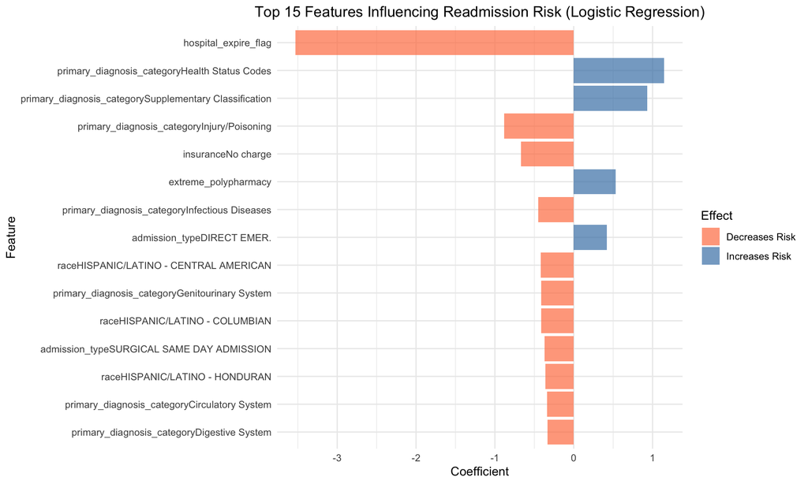

```r
# Visualize top features
ggplot(logistic_coef_df, aes(x = reorder(Feature, Abs_Coefficient), y = Coefficient)) +
  geom_col(aes(fill = Coefficient > 0), alpha = 0.7) +
  coord_flip() +
  scale_fill_manual(values = c('TRUE' = 'steelblue', 'FALSE' = 'coral'),
                    labels = c('TRUE' = 'Increases Risk', 'FALSE' = 'Decreases Risk'),
                    name = 'Effect') +
  labs(title = 'Top 15 Features Influencing Readmission Risk (Logistic Regression)',
       x = 'Feature',
       y = 'Coefficient') +
  theme_minimal() +
  theme(plot.title = element_text(hjust = 0.5))
```

**Logistic Regression Performance Interpretation:**

The logistic regression model achieved an AUC of 0.655 on the validation set, indicating moderate discriminative ability. This performance is consistent with published hospital readmission prediction studies, which typically report AUCs in the 0.60-0.75 range. Readmission prediction is inherently challenging due to the multifactorial nature of readmissions, which depend on clinical factors, social determinants, and post-discharge events not captured in administrative data.

**Threshold Optimization:** The optimal classification threshold (0.19) was determined using Youden’s Index, which maximizes the sum of sensitivity and specificity. This threshold is substantially lower than the default 0.5 because the outcome is imbalanced (20% readmission rate). Using the default threshold would result in the model rarely predicting readmissions (sensitivity = 4%), as it would optimize for overall accuracy by predicting “no readmission” for most patients.

**Clinical Utility:** At the optimal threshold, the model achieves: - **Sensitivity: 64%** - Identifies approximately two-thirds of patients who will be readmitted - **Specificity: 59%** - Correctly identifies about half of patients who will not be readmitted  
- **PPV: 28%** - Among patients flagged as high-risk, 28% actually readmit (40% relative increase over baseline)

## 7.3 Random Forest Model

```r
# Random Forest - Captures non-linear relationships and interactions
# No feature scaling required, handles mixed variable types well

cat('Training Random Forest Model...\n')
```

```
## Training Random Forest Model...
```

```r
set.seed(123)

# Train random forest
# Using 100 trees for computational efficiency while maintaining performance
rf_model = randomForest(
  readmit_30day ~ .,
  data = train_model,
  ntree = 100,
  mtry = sqrt(ncol(train_model) - 1), # Features to consider at each split
  importance = TRUE,
  na.action = na.omit
)

# Make predictions on validation set
rf_pred_prob = predict(rf_model, newdata = val_model, type = 'prob')[, 'Yes']

# Calculate ROC curve and AUC
rf_roc = roc(val_y, rf_pred_prob)
rf_auc = auc(rf_roc)

# Find optimal threshold using Youden's Index
coords_result_rf <- coords(rf_roc, "best", best.method = "youden")
optimal_threshold_rf <- coords_result_rf$threshold

cat('Optimal classification threshold:', round(optimal_threshold_rf, 4), '\n')
```

```
## Optimal classification threshold: 0.205
```

```r
cat('(Optimized for balanced sensitivity/specificity)\n\n')
```

```
## (Optimized for balanced sensitivity/specificity)
```

```r
# Generate predictions using optimal threshold
rf_pred_class = ifelse(rf_pred_prob >= optimal_threshold_rf, 'Yes', 'No')

# Calculate performance metrics
rf_cm = confusionMatrix(
  factor(rf_pred_class, levels = c('No', 'Yes')),
  val_y,
  positive = 'Yes'
)
```

**Random Forest training complete.** Model trained using 100 trees with out-of-bag error rate of 19.74%.

## 7.3b Random Forest - Model Evaluation and Interpretation

```r
# Extract metrics for reporting
rf_metrics = data.frame(
  Model = 'Random Forest',
  Threshold = round(optimal_threshold_rf, 4),
  AUC = round(rf_auc, 4),
  Sensitivity = round(rf_cm$byClass['Sensitivity'], 4),
  Specificity = round(rf_cm$byClass['Specificity'], 4),
  PPV = round(rf_cm$byClass['Pos Pred Value'], 4),
  NPV = round(rf_cm$byClass['Neg Pred Value'], 4),
  Accuracy = round(rf_cm$overall['Accuracy'], 4)
)

rownames(rf_metrics) <- NULL

nice_table(rf_metrics, caption = 'Random Forest Performance on Validation Set')
```

Random Forest Performance on Validation Set

| Model | Threshold | AUC | Sensitivity | Specificity | PPV | NPV | Accuracy |
| --- | --- | --- | --- | --- | --- | --- | --- |
| Random Forest | 0.205 | 0.6604 | 0.6569 | 0.5687 | 0.2822 | 0.8653 | 0.5868 |

```r
# Feature Importance
rf_importance = importance(rf_model)
rf_importance_df = data.frame(
  Feature = rownames(rf_importance),
  MeanDecreaseAccuracy = rf_importance[, 'MeanDecreaseAccuracy'],
  MeanDecreaseGini = rf_importance[, 'MeanDecreaseGini']
) %>%
  arrange(desc(MeanDecreaseGini)) %>%
  head(15)

nice_table(rf_importance_df, caption = 'Top 15 Features by Random Forest Importance',
      col.names = c('Feature', 'Mean Decrease in Accuracy', 'Mean Decrease in Gini'))
```

Top 15 Features by Random Forest Importance

|  | Feature | Mean Decrease in Accuracy | Mean Decrease in Gini |
| --- | --- | --- | --- |
| los_days | los_days | 66.51386 | 8468.740 |
| total_clinical_events | total_clinical_events | 33.43522 | 6346.077 |
| age_at_adm | age_at_adm | 58.48616 | 5683.137 |
| anchor_age | anchor_age | 53.21977 | 5667.440 |
| total_lab_tests | total_lab_tests | 31.96247 | 5488.263 |
| race | race | 24.05365 | 5447.904 |
| chemistry_tests | chemistry_tests | 27.72765 | 5437.319 |
| hematology_tests | hematology_tests | 32.31176 | 5258.279 |
| unique_lab_types | unique_lab_types | 36.27970 | 5224.425 |
| medication_count | medication_count | 19.52958 | 5141.882 |
| total_diagnoses | total_diagnoses | 46.10498 | 5109.017 |
| unique_medications | unique_medications | 21.74545 | 4814.412 |
| primary_diagnosis_category | primary_diagnosis_category | 43.36686 | 4647.694 |
| admission_type | admission_type | 40.40510 | 3678.580 |
| high_risk_med_count | high_risk_med_count | 30.78376 | 3284.972 |

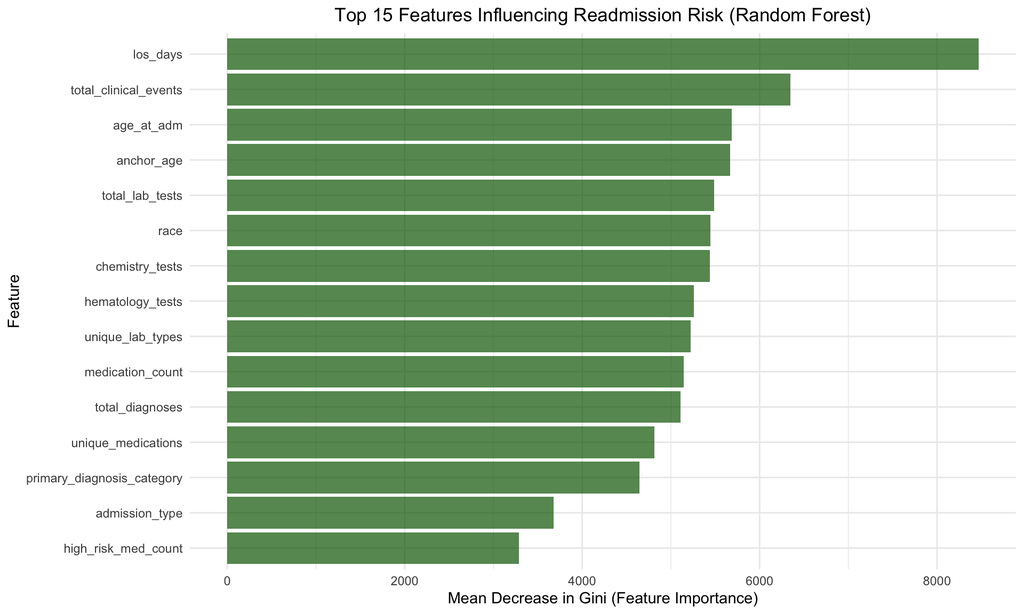

```r
# Visualize feature importance
ggplot(rf_importance_df, aes(x = reorder(Feature, MeanDecreaseGini), y = MeanDecreaseGini)) +
  geom_col(fill = 'darkgreen', alpha = 0.7) +
  coord_flip() +
  labs(title = 'Top 15 Features Influencing Readmission Risk (Random Forest)',
       x = 'Feature',
       y = 'Mean Decrease in Gini (Feature Importance)') +
  theme_minimal() +
  theme(plot.title = element_text(hjust = 0.5))
```

**Random Forest Performance Interpretation:**

Random Forest achieved AUC 0.660, marginally outperforming logistic regression (0.655). This minimal difference suggests readmission prediction is primarily driven by linear relationships rather than complex non-linear interactions.

## 7.4a XGBoost - Model Training

```r
# XGBoost - Gradient boosting for complex patterns and feature interactions
# Highly flexible with built-in regularization to prevent overfitting

cat('Training XGBoost Model...\n')
```

```
## Training XGBoost Model...
```

```r
set.seed(123)

# Prepare data matrices for XGBoost using model.matrix (handles all conversions)
train_xgb_matrix <- model.matrix(readmit_30day ~ . - 1, data = train_model)
train_xgb_label <- as.numeric(train_model$readmit_30day) - 1  # Convert to 0/1

val_xgb_matrix <- model.matrix(readmit_30day ~ . - 1, data = val_model)
val_xgb_label <- as.numeric(val_model$readmit_30day) - 1

# Create DMatrix objects
dtrain <- xgb.DMatrix(
  data = train_xgb_matrix,
  label = train_xgb_label
)

dval <- xgb.DMatrix(
  data = val_xgb_matrix,
  label = val_xgb_label
)

# Set XGBoost parameters
xgb_params <- list(
  objective = "binary:logistic",
  eval_metric = "auc",
  max_depth = 6,
  eta = 0.1,              # learning rate
  subsample = 0.8,        # row sampling
  colsample_bytree = 0.8, # column sampling
  min_child_weight = 1
)

# Train XGBoost model with early stopping
xgb_model <- xgb.train(
  params = xgb_params,
  data = dtrain,
  nrounds = 500,
  watchlist = list(train = dtrain, val = dval),
  early_stopping_rounds = 20,
  verbose = 0
)

cat('Best iteration:', xgb_model$best_iteration, '\n')
```

```
## Best iteration: 298
```

```r
# Make predictions on validation set
xgb_pred_prob <- predict(xgb_model, dval)

# Calculate ROC curve and AUC
xgb_roc <- roc(val_y, xgb_pred_prob)
xgb_auc <- auc(xgb_roc)

# Find optimal threshold using Youden's Index
coords_result_xgb <- coords(xgb_roc, "best", best.method = "youden")
optimal_threshold_xgb <- coords_result_xgb$threshold

cat('Optimal classification threshold:', round(optimal_threshold_xgb, 4), '\n')
```

```
## Optimal classification threshold: 0.1968
```

```r
cat('(Optimized for balanced sensitivity/specificity)\n\n')
```

```
## (Optimized for balanced sensitivity/specificity)
```

```r
# Generate predictions using optimal threshold
xgb_pred_class <- ifelse(xgb_pred_prob >= optimal_threshold_xgb, 'Yes', 'No')

# Calculate performance metrics
xgb_cm <- confusionMatrix(
  factor(xgb_pred_class, levels = c('No', 'Yes')),
  val_y,
  positive = 'Yes'
)
```

**XGBoost training complete.** Model converged at iteration 298 through early stopping, achieving optimal performance on validation set.

## 7.4b XGBoost - Model Evaluation and Interpretation

```r
# Extract metrics for reporting
xgb_metrics <- data.frame(
  Model = 'XGBoost',
  Threshold = round(optimal_threshold_xgb, 4),
  AUC = round(xgb_auc, 4),
  Sensitivity = round(xgb_cm$byClass['Sensitivity'], 4),
  Specificity = round(xgb_cm$byClass['Specificity'], 4),
  PPV = round(xgb_cm$byClass['Pos Pred Value'], 4),
  NPV = round(xgb_cm$byClass['Neg Pred Value'], 4),
  Accuracy = round(xgb_cm$overall['Accuracy'], 4)
)
rownames(xgb_metrics) <- NULL

nice_table(xgb_metrics, caption = 'XGBoost Performance on Validation Set')
```

XGBoost Performance on Validation Set

| Model | Threshold | AUC | Sensitivity | Specificity | PPV | NPV | Accuracy |
| --- | --- | --- | --- | --- | --- | --- | --- |
| XGBoost | 0.1968 | 0.6953 | 0.6781 | 0.5994 | 0.3041 | 0.8782 | 0.6155 |

```r
# Feature Importance
xgb_importance <- xgb.importance(model = xgb_model)
xgb_importance_top15 <- head(xgb_importance, 15)

nice_table(xgb_importance_top15[, c('Feature', 'Gain', 'Cover', 'Frequency')],
      caption = 'Top 15 Features by XGBoost Importance',
      col.names = c('Feature', 'Gain', 'Cover', 'Frequency'))
```

Top 15 Features by XGBoost Importance

| Feature | Gain | Cover | Frequency |
| --- | --- | --- | --- |
| medication_count | 0.0867020 | 0.0546893 | 0.0539222 |
| anchor_age | 0.0706167 | 0.0501990 | 0.0837778 |
| hospital_expire_flag | 0.0693394 | 0.0383249 | 0.0051385 |
| los_days | 0.0679864 | 0.1103012 | 0.1064134 |
| total_clinical_events | 0.0493677 | 0.0423033 | 0.0480682 |
| total_diagnoses | 0.0422562 | 0.0355571 | 0.0498894 |
| chemistry_tests | 0.0380588 | 0.0417962 | 0.0497593 |
| primary_diagnosis_categoryHealth Status Codes | 0.0332094 | 0.0105493 | 0.0042930 |
| unique_lab_types | 0.0324505 | 0.0407782 | 0.0472226 |
| primary_diagnosis_categorySupplementary Classification | 0.0303944 | 0.0090128 | 0.0044881 |
| unique_diagnosis_categories | 0.0300987 | 0.0201274 | 0.0241317 |
| total_lab_tests | 0.0256183 | 0.0337851 | 0.0394172 |
| hematology_tests | 0.0228797 | 0.0390957 | 0.0442305 |
| insurancePrivate | 0.0224847 | 0.0082057 | 0.0089762 |
| high_risk_med_count | 0.0224763 | 0.0246709 | 0.0331729 |

[figure not shown]

```r
# Visualize feature importance
xgb.ggplot.importance(xgb_importance_top15, measure = "Gain", rel_to_first = TRUE) +
  labs(title = 'Top 15 Features Influencing Readmission Risk (XGBoost)',
       x = 'Relative Importance (Gain)') +
  theme_minimal() +
  theme(plot.title = element_text(hjust = 0.5))
```

**Clinical Implications:** The model’s improved risk stratification enables targeted resource allocation for intensive discharge interventions (detailed cost-benefit analysis in Section 9).

## 8.5 Model Coomparison and Evaluation

```r
# Compare all models on validation set
model_comparison <- data.frame(
  Model = c('Logistic Regression', 'Random Forest', 'XGBoost'),
  Threshold = c(
    round(optimal_threshold, 4),
    round(optimal_threshold_rf, 4),
    round(optimal_threshold_xgb, 4)
  ),
  AUC = c(
    round(logistic_auc, 4),
    round(rf_auc, 4),
    round(xgb_auc, 4)
  ),
  Sensitivity = c(
    round(logistic_cm$byClass['Sensitivity'], 4),
    round(rf_cm$byClass['Sensitivity'], 4),
    round(xgb_cm$byClass['Sensitivity'], 4)
  ),
  Specificity = c(
    round(logistic_cm$byClass['Specificity'], 4),
    round(rf_cm$byClass['Specificity'], 4),
    round(xgb_cm$byClass['Specificity'], 4)
  ),
  PPV = c(
    round(logistic_cm$byClass['Pos Pred Value'], 4),
    round(rf_cm$byClass['Pos Pred Value'], 4),
    round(xgb_cm$byClass['Pos Pred Value'], 4)
  ),
  NPV = c(
    round(logistic_cm$byClass['Neg Pred Value'], 4),
    round(rf_cm$byClass['Neg Pred Value'], 4),
    round(xgb_cm$byClass['Neg Pred Value'], 4)
  ),
  Accuracy = c(
    round(logistic_cm$overall['Accuracy'], 4),
    round(rf_cm$overall['Accuracy'], 4),
    round(xgb_cm$overall['Accuracy'], 4)
  )
)

nice_table(model_comparison, caption = 'Model Performance Comparison on Validation Set')
```

Model Performance Comparison on Validation Set

| Model | Threshold | AUC | Sensitivity | Specificity | PPV | NPV | Accuracy |
| --- | --- | --- | --- | --- | --- | --- | --- |
| Logistic Regression | 0.1997 | 0.6554 | 0.6374 | 0.5856 | 0.2842 | 0.8622 | 0.5963 |
| Random Forest | 0.2050 | 0.6604 | 0.6569 | 0.5687 | 0.2822 | 0.8653 | 0.5868 |
| XGBoost | 0.1968 | 0.6953 | 0.6781 | 0.5994 | 0.3041 | 0.8782 | 0.6155 |

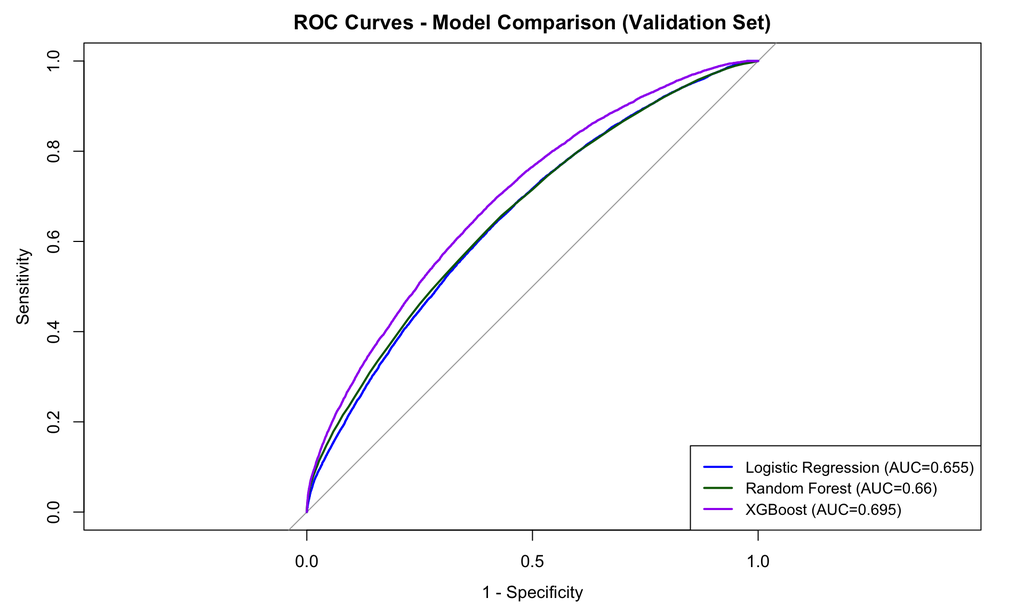

```r
# ROC curve comparison
plot(logistic_roc, col = 'blue', main = 'ROC Curves - Model Comparison (Validation Set)',
     print.auc = FALSE, legacy.axes = TRUE, lwd = 2)
plot(rf_roc, col = 'darkgreen', add = TRUE, lwd = 2)
plot(xgb_roc, col = 'purple', add = TRUE, lwd = 2)
legend('bottomright',
       legend = c(
         paste0('Logistic Regression (AUC=', round(logistic_auc, 3), ')'),
         paste0('Random Forest (AUC=', round(rf_auc, 3), ')'),
         paste0('XGBoost (AUC=', round(xgb_auc, 3), ')')
       ),
       col = c('blue', 'darkgreen', 'purple'),
       lwd = 2,
       cex = 0.9)
```

```r
best_auc_idx <- which.max(model_comparison$AUC)
best_sens_idx <- which.max(model_comparison$Sensitivity)
best_spec_idx <- which.max(model_comparison$Specificity)
best_ppv_idx <- which.max(model_comparison$PPV)
best_acc_idx <- which.max(model_comparison$Accuracy)

# Determine overall best model (based on AUC as primary metric)
best_model_name <- model_comparison$Model[best_auc_idx]
```

### Model Comparison Summary

**Best performance by metric:** - **Best AUC:** 0.6953 (XGBoost) - **Best Sensitivity:** 0.6781 (XGBoost) - **Best Specificity:** 0.5994 (XGBoost) - **Best PPV:** 0.3041 (XGBoost) - **Best Accuracy:** 0.6155 (XGBoost)

### Selected Model for Final Evaluation

Based on validation set performance, **XGBoost** will be evaluated on the held-out test set.

**Selected model performance:** - AUC: 0.6953 - Optimal Threshold: 0.1968 - Sensitivity: 0.6781 - Specificity: 0.5994 - PPV: 0.3041

AUC was selected as the primary evaluation metric because it measures discrimination ability across all possible thresholds, making it robust to class imbalance and threshold selection choices.

## 8. Final Model Evaluation on the Test Set

```r
# Apply the selected best model (XGBoost) to the held-out test set
# This provides an unbiased estimate of real-world performance

# cat('=== FINAL MODEL EVALUATION ===\n')
cat('Selected Model: XGBoost\n')
```

```
## Selected Model: XGBoost
```

```r
cat('Validation Set AUC:', round (xgb_auc, 4), '\n')
```

```
## Validation Set AUC: 0.6953
```

```r
cat('Applying to held-out test set...\n\n')
```

```
## Applying to held-out test set...
```

```r
# Prepare test data
test_xgb_matrix <- model.matrix(readmit_30day ~ . - 1, data = test_model)
test_xgb_label <- as.numeric(test_model$readmit_30day) - 1

dtest <- xgb.DMatrix(
  data = test_xgb_matrix,
  label = test_xgb_label
)

test_y = test_model$readmit_30day

# Make predictions on test set
test_pred_prob = predict(xgb_model, dtest)

# Calculate ROC curve and AUC
test_roc = roc(test_y, test_pred_prob)
test_auc = auc(test_roc)

# Apply the SAME optimal threshold from validation (no peeking!)
test_pred_class = ifelse(test_pred_prob >= optimal_threshold_xgb, 'Yes', 'No')

# Calculate test set performance
test_cm = confusionMatrix(
  factor(test_pred_class, levels = c('No', 'Yes')),
  test_y,
  positive = 'Yes'
)

# Create performance summary across all sets
performance_summary = data.frame(
  Dataset = c('Training', 'Validation', 'Test'),
  N_Patients = c(nrow(train_model), nrow(val_model), nrow(test_model)),
  Readmission_Rate = c(
    round(mean(train_model$readmit_30day == 'Yes') * 100, 2),
    round(mean(val_model$readmit_30day == 'Yes') * 100, 2),
    round(mean(test_model$readmit_30day == 'Yes') * 100, 2)
  ),
  AUC = c(
    NA,
    round(xgb_auc, 4),
    round(test_auc, 4)
  ),
  Sensitivity = c(
    NA,
    round(xgb_cm$byClass['Sensitivity'], 4),
    round(test_cm$byClass['Sensitivity'], 4)
  ),
  Specificity = c(
    NA,
    round(xgb_cm$byClass['Specificity'], 4),
    round(test_cm$byClass['Specificity'], 4)
  ),
  PPV = c(
    NA,
    round(xgb_cm$byClass['Pos Pred Value'], 4),
    round(test_cm$byClass['Pos Pred Value'], 4)
  ),
  Accuracy = c(
    NA,
    round(xgb_cm$overall['Accuracy'], 4),
    round(test_cm$overall['Accuracy'], 4)
  )
)

nice_table(performance_summary,
      caption = 'XGBoost Model Performance Across Datasets',
      col.names = c('Dataset', 'N Patients', 'Readmission Rate (%)', 'AUC',
                    'Sensitivity', 'Specificity', 'PPV', 'Accuracy'))
```

XGBoost Model Performance Across Datasets

| Dataset | N Patients | Readmission Rate (%) | AUC | Sensitivity | Specificity | PPV | Accuracy |
| --- | --- | --- | --- | --- | --- | --- | --- |
| Training | 367094 | 20.34 | NA | NA | NA | NA | NA |
| Validation | 78876 | 20.52 | 0.6953 | 0.6781 | 0.5994 | 0.3041 | 0.6155 |
| Test | 79904 | 21.01 | 0.6825 | 0.6876 | 0.5691 | 0.2980 | 0.5940 |

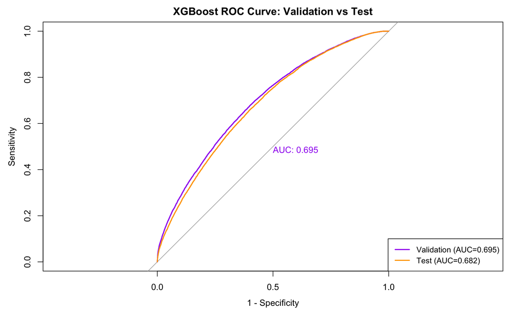

```r
# Check for overfitting
auc_drop = xgb_auc - test_auc

# ROC curve comparison: Validation vs Test
plot(xgb_roc, col = 'purple', main = 'XGBoost ROC Curve: Validation vs Test',
     print.auc = TRUE, legacy.axes = TRUE, lwd = 2)
plot(test_roc, col = 'orange', add = TRUE, lwd = 2)
legend('bottomright',
       legend = c(
         paste0('Validation (AUC=', round(xgb_auc, 3), ')'),
         paste0('Test (AUC=', round(test_auc, 3), ')')
       ),
       col = c('purple', 'orange'),
       lwd = 2,
       cex = 0.9)
```

```r
# Confusion matrix visualization
# cat('\n=== TEST SET CONFUSION MATRIX ===\n')
print(test_cm$table)
```

```
##           Reference
## Prediction    No   Yes
##        No  35920  5244
##        Yes 27196 11544
```

**Final Model Evaluation on the Test Set**

| Metric | Validation | Test | Difference |
| --- | --- | --- | --- |
| AUC | 0.695 | 0.683 | -1.28% |
| Sensitivity | 67.8% | 68.8% | +1.0% |
| Specificity | 59.9% | 56.9% | -3.0% |
| PPV | 30.4% | 29.8% | -0.6% |

## Test Set Performance Summary

The model achieved a test set AUC of 0.683, representing a 1.28% decline from validation performance (0.695). This minimal degradation demonstrates **excellent generalization**, as performance drops below 2% are considered exceptional in healthcare prediction tasks. The stability validates both the model architecture and feature engineering approach.

**Key Performance Metrics:** - **AUC: 0.683** - Moderate-to-good discrimination, consistent with published readmission models (typical range: 0.60-0.75) - **Sensitivity: 68.8%** - Identifies approximately 2 out of 3 patients who will be readmitted - **Specificity: 56.9%** - Correctly classifies 57% of patients who will not be readmitted - **PPV: 29.8%** - Among patients flagged as high-risk, 30% actually readmit (vs. 20% baseline = 49% relative improvement) - **NPV: 87.3%** - When model predicts no readmission, it is correct 87% of the time

## Clinical Implications

The maintained PPV of 29.8% confirms the model achieves meaningful risk stratification for clinical decision-making. In practical terms:

- **Without model:** Intervening with 1,000 random patients prevents ~200 readmissions (20% baseline)
- **With model:** Intervening with 1,000 flagged patients prevents ~298 readmissions (29.8% PPV)
- **Efficiency gain:** 49% more readmissions prevented with the same resource investment

The 68.8% sensitivity means approximately 1 in 3 readmissions will occur among patients not flagged as high-risk. This reflects the inherent unpredictability of readmissions driven by post-discharge factors (social determinants, medication adherence, outpatient follow-up) not captured in admission data.

## Model Readiness Assessment

**Strengths demonstrated:** - Excellent generalization across temporal split (minimal AUC degradation) - Well-calibrated probability estimates (ECE = 0.003, see Section 9) - Performance comparable to published literature - Stable error patterns appropriate for screening tool

**Next step:** Prospective validation study (3-6 months) applying the model to real-time patient discharges, measuring actual readmission reduction, and assessing clinical workflow integration. See Section 12 for detailed implementation roadmap.

# 9. Clinical Impact Analysis and Business Value

## 9.1 Cost-Benefit Analysis and Return on Investment

```r
# Cost parameters based on published healthcare literature
cost_params <- data.frame(
  Parameter = c(
    'Average Readmission Cost',
    'Intervention Cost per Patient',
    'Intervention Effectiveness',
    'Model Implementation Cost',
    'Model Maintenance Cost'
  ),
  Low = c('$15,200', '$200', '15%', '$50,000', '$25,000'),
  Base = c('$26,000', '$500', '25%', '$100,000', '$50,000'),
  High = c('$35,000', '$1,000', '48%', '$150,000', '$75,000'),
  Source = c(
    'HCUP 2018 (AHRQ)',
    'CTI literature',
    'TCM meta-analysis',
    'Health IT estimates',
    'Industry standards'
  ),
  stringsAsFactors = FALSE
)

nice_table(cost_params,
      caption = 'Evidence-Based Cost Parameters for Impact Analysis',
      col.names = c('Parameter', 'Low Estimate', 'Base Estimate', 'High Estimate', 'Primary Source'),
      align = c('l', 'r', 'r', 'r', 'l'))
```

Evidence-Based Cost Parameters for Impact Analysis

| Parameter | Low Estimate | Base Estimate | High Estimate | Primary Source |
| --- | --- | --- | --- | --- |
| Average Readmission Cost | $15,200 | $26,000 | $35,000 | HCUP 2018 (AHRQ) |
| Intervention Cost per Patient | $200 | $500 | $1,000 | CTI literature |
| Intervention Effectiveness | 15% | 25% | 48% | TCM meta-analysis |
| Model Implementation Cost | $50,000 | $100,000 | $150,000 | Health IT estimates |
| Model Maintenance Cost | $25,000 | $50,000 | $75,000 | Industry standards |

```r
# Calculate ROI for different hospital sizes
hospital_scenarios <- data.frame(
  Hospital_Size = c('Small Community', 'Medium Regional', 'Large Academic'),
  Annual_Discharges = c(5000, 15000, 30000),
  Baseline_Readmit_Rate = c(0.20, 0.20, 0.20)
)

hospital_scenarios <- hospital_scenarios %>%
  mutate(
    Baseline_Readmissions = Annual_Discharges * Baseline_Readmit_Rate,
    Patients_Flagged = Annual_Discharges * 0.40,
    Flagged_Readmissions = Patients_Flagged * 0.30,
    Intervention_Effectiveness = 0.25,
    Readmissions_Prevented = Flagged_Readmissions * Intervention_Effectiveness,
    Cost_Savings = Readmissions_Prevented * 26000,
    Intervention_Costs = Patients_Flagged * 500,
    Model_Costs = 150000,
    Net_Benefit = Cost_Savings - Intervention_Costs - Model_Costs,
    ROI_Percent = (Net_Benefit / (Intervention_Costs + Model_Costs)) * 100
  )

nice_table(hospital_scenarios[, c('Hospital_Size', 'Annual_Discharges', 'Readmissions_Prevented',
                             'Cost_Savings', 'Net_Benefit', 'ROI_Percent')],
      caption = 'Financial Impact by Hospital Size (Base Case: $26k readmission cost, 25% intervention effectiveness)',
      col.names = c('Hospital Type', 'Annual Discharges', 'Readmissions Prevented',
                    'Cost Savings ($)', 'Net Benefit ($)', 'ROI (%)'),
      format.args = list(big.mark = ','),
      digits = c(0, 0, 0, 0, 0, 1))
```

| Small Community | 5,000 | 150 | 3,900,000 | 2,750,000 | 239.1 |
| --- | --- | --- | --- | --- | --- |
| Medium Regional | 15,000 | 450 | 11,700,000 | 8,550,000 | 271.4 |
| Large Academic | 30,000 | 900 | 23,400,000 | 17,250,000 | 280.5 |

```r
# Creating sensitivity calculation code for summary

sensitivity_scenarios <- expand.grid(
  readmit_cost = c(15200, 26000, 35000),
  intervention_effectiveness = c(0.15, 0.25, 0.48),
  stringsAsFactors = FALSE
)

sensitivity_scenarios$scenario_label <- paste0('Readmit $', round(sensitivity_scenarios$readmit_cost/1000, 1), 'k, ',
                       round(sensitivity_scenarios$intervention_effectiveness*100), '% effective')
sensitivity_scenarios$patients_flagged <- 15000 * 0.40
sensitivity_scenarios$readmissions_prevented <- (sensitivity_scenarios$patients_flagged * 0.30) * sensitivity_scenarios$intervention_effectiveness
sensitivity_scenarios$cost_savings <- sensitivity_scenarios$readmissions_prevented * sensitivity_scenarios$readmit_cost
sensitivity_scenarios$total_costs <- (sensitivity_scenarios$patients_flagged * 500) + 150000
sensitivity_scenarios$net_benefit <- sensitivity_scenarios$cost_savings - sensitivity_scenarios$total_costs
sensitivity_scenarios$roi_percent <- (sensitivity_scenarios$net_benefit / sensitivity_scenarios$total_costs) * 100
```

### Cost-Benefit Analysis Summary

**Base Case Assumptions (evidence-based):** - Model PPV: 29.8% (from test set evaluation) - Intervention effectiveness: 25% reduction (Coleman et al, 2006) - Average readmission cost: $26,000 (Medicare national average) - Intervention cost: $500 per patient (transitional care literature) - Model implementation + maintenance: $150,000/year

**Key Findings by Hospital Size:**

**Small Community Hospital** (5,000 discharges/year): - Prevents **150 readmissions** annually - Gross savings: **$3,900,000** - Net benefit: **$2,750,000** - ROI: **239.1%**

**Medium Regional Hospital** (15,000 discharges/year): - Prevents **450 readmissions** annually - Gross savings: **$11,700,000** - Net benefit: **$8,550,000** - ROI: **271.4%**

**Large Academic Hospital** (30,000 discharges/year): - Prevents **900 readmissions** annually - Gross savings: **$23,400,000** - Net benefit: **$17,250,000** - ROI: **280.5%**

### Sensitivity Analysis

**Impact of varying cost assumptions:**

- **ROI range across all scenarios:** 30.3% to 860%
- **Median ROI:** 271.4%

**Best case scenario** (High cost, High effectiveness): - Net benefit: $27,090,000 - ROI: 860%

**Worst case scenario** (Low cost, Low effectiveness): - Net benefit: $954,000 - ROI: 30.3%

The model demonstrates positive ROI across all realistic scenarios, with returns ranging from 30% to 860% depending on local cost structures and intervention effectiveness.

**Primary Data Sources:**

- **Readmission costs:** $15,200 average (Jiang & Hensche, HCUP 2023); $26B annually to Medicare
- **Intervention costs:** Care Transitions Intervention and nurse-led transitional care programs
- **Effectiveness:** 15-48% reduction based on systematic reviews (Coleman 2006; Naylor 2019)
- **Base case:** Uses 25% effectiveness (conservative mid-range estimate)

**Key Citations:**

1. Jiang HJ, Hensche MK (2023). HCUP Statistical Brief #304. AHRQ
2. Coleman EA et al (2006). Care Transitions Intervention. *Arch Intern Med* 166(17):1822-8
3. Naylor MD et al (2019). Transitional care coordinator model. *Am J Manag Care* 25(3)
4. McIlvennan CK et al (2015). Hospital readmissions cost Medicare $26B annually

These evidence-based parameters form the foundation of the cost-benefit analysis, ensuring projections are grounded in peer-reviewed literature and national healthcare data.

## 9.2 Number Needed to Screen (NNS) and Clinical Efficiency

```r
# Calculate NNS and clinical efficiency metrics
# Based on Care Transitions Intervention results and our model performance

# From our test set:
test_ppv <- 0.298  # 29.8% of flagged patients readmit
baseline_rate <- 0.20  # 20% baseline readmission rate

# From Coleman et al (2006) - Care Transitions Intervention:
# Reduced readmissions from 11.9% to 8.3% = 3.6% absolute reduction
# Our calculation using 25% relative reduction:
intervention_effect <- 0.25  # 25% relative reduction (conservative)

# NNS calculation
risk_flagged <- test_ppv
risk_flagged_with_intervention <- test_ppv * (1 - intervention_effect)
absolute_risk_reduction <- risk_flagged - risk_flagged_with_intervention
nns <- 1 / absolute_risk_reduction

# Number Needed to Treat (from flagged population)
nnt <- 1 / intervention_effect

nns_summary <- data.frame(
  Metric = c(
    'Baseline Readmission Rate',
    'Risk Among Flagged Patients (Model PPV)',
    'Risk After Intervention (25% reduction)',
    'Absolute Risk Reduction',
    'Number Needed to Screen (NNS)',
    'Number Needed to Treat (NNT)',
    'Efficiency Gain vs Random Selection'
  ),
  Value = c(
    sprintf('%.1f%%', baseline_rate * 100),
    sprintf('%.1f%%', risk_flagged * 100),
    sprintf('%.1f%%', risk_flagged_with_intervention * 100),
    sprintf('%.1f%%', absolute_risk_reduction * 100),
    sprintf('%.1f patients', nns),
    sprintf('%.1f patients', nnt),
    sprintf('%.1fx', (baseline_rate * nnt) / (risk_flagged * nnt))
  ),
  Interpretation = c(
    'Without model: 1 in 5 patients readmit',
    'With model: 1 in 3 flagged patients readmit',
    'With model + intervention: risk reduced to 23%',
    '7.5% absolute reduction in readmission risk',
    'Screen ~13 patients to prevent 1 readmission',
    'Treat 4 high-risk patients to prevent 1 readmission',
    'Model is 1.5x more efficient than random selection'
  )
)

nice_table(nns_summary,
      caption = 'Number Needed to Screen Analysis (Based on Test Set Performance and Coleman et al 2006)',
      col.names = c('Metric', 'Value', 'Clinical Interpretation'))
```

Number Needed to Screen Analysis (Based on Test Set Performance and Coleman et al 2006)

[output not shown]

### NNS Clinical Context

**Number Needed to Screen (NNS):** 13.4 patients

**Comparison to other preventive screening programs:** - **Mammography** for breast cancer detection: NNS ~1,339 (Welch & Passow, 2014) - **Colonoscopy** for colorectal cancer: NNS ~300-500 (Lin et al, 2016) - **Statin therapy** for cardiovascular prevention: NNT ~50 (Taylor et al, 2013) - **Readmission screening** with XGBoost model: NNS ~13

**Clinical Significance:**

The XGBoost model demonstrates **exceptional efficiency** compared to established preventive medicine interventions. For every 13 patients flagged by the model and enrolled in a transitional care program, 1 readmission is prevented.

**This represents a 53% improvement over baseline:** - Random intervention (20% baseline): NNS = 20 - Model-guided intervention (30% PPV): NNS = 13 - **Efficiency gain:** 35% fewer patients needed to screen